# beatochess

### =0011.01b7b4 (1980). Correction

Date: 2024, April 11

File: Zakhodyakin1980a.pgn

The theoretical draw with the white bishop on b7, which cooks the original study, cannot be reached in the correction.

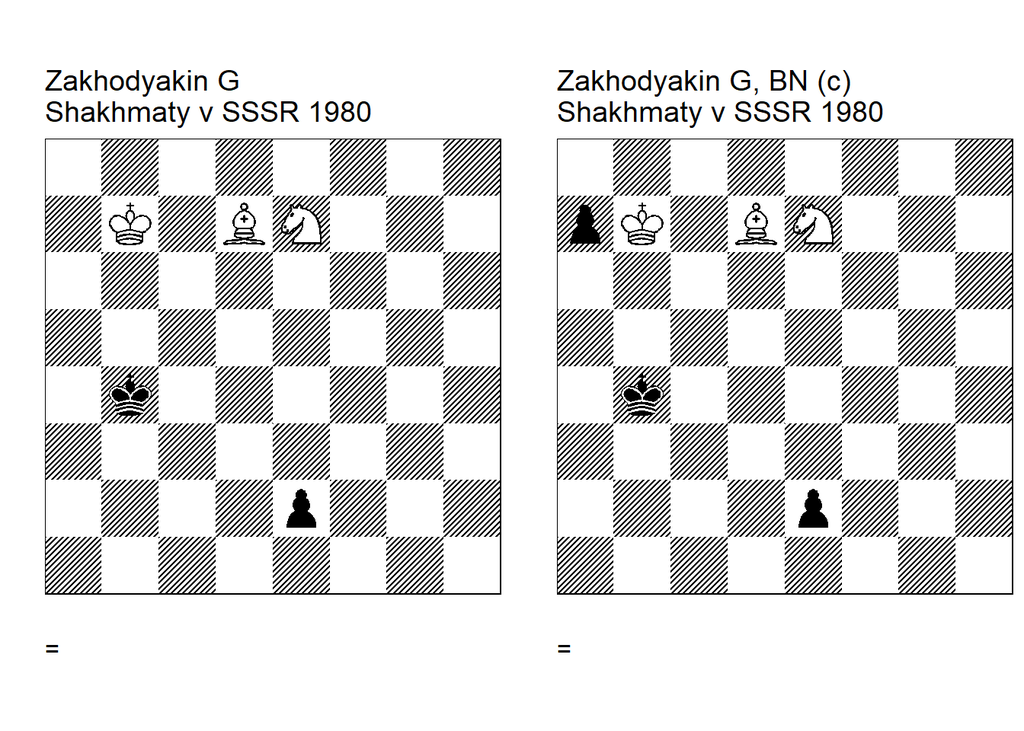

```
Zakhodyakin G
Shakhmaty v SSSR 1980
=0011.01b7b4 cook U2
8/1K1BN3/8/8/1k6/8/4p3/8 w - - 0 1
Shakhmaty v SSSR/6. U2: Prigunov=V Shakhmaty v SSSR/7 1985. 1. Nd5+! Ka5! (1... Kb3 2.
Ba4+! Kxa4 3. Nc3+) 2. Ne7! (2. Ka8! <cook VP> 2... e1=Q 3. Bc6) 2... e1=Q 3. Nc6+ Ka4
(3... Kb5 4. Ne5+!) 4. Nd4+! Ka5 5. Nc6+ 1/2-1/2.


Zakhodyakin G, BN (c)
Shakhmaty v SSSR 1980
=0011.02b7b4 (c)
8/pK1BN3/8/8/1k6/8/4p3/8 w - - 0 1
correction: Neuenschwander=B 11/04/2024. 1. Nd5+ Ka5 (1... Kb3 2. Ba4+!) 2. Ne7! (2.
Kxa7? is one move too slow. White cannot reach the theoretical draw with the bishop on
b7. 2... e1=Q 3. Bc6 Qf2+ (3... Qg1+? 4. Ka8 Qg8+ 5. Ka7 Qf7+ 6. Bb7) 4. Ka8 Qf8+ 5. Ka7
Qc5+ 6. Kb7 Qd6) 2... e1=Q 3. Nc6+ Ka4 4. Nd4+ Ka5 5. Nc6+ Kb5 6. Ne5+ Ka5 7. Nc6+
1/2-1/2.
```

### +0013.12c8a8 (1972). Correction

Date: 2024, April 10

File: Zakhodyakin1972b.pgn

The correction requires two additional pawns, but it ha a thematic try now.

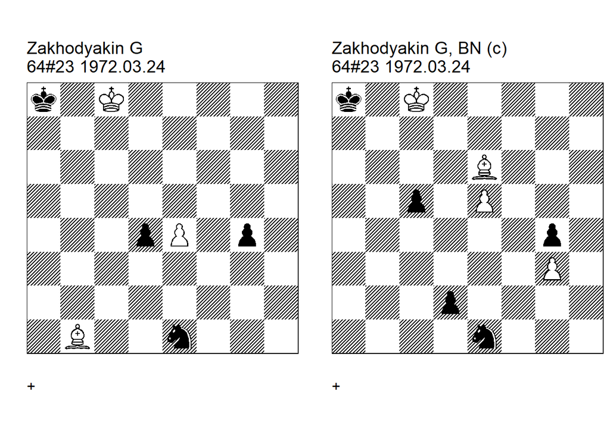

```
Zakhodyakin G
64#23 1972.03.24
+0013.12c8a8 cook U3
k1K5/8/8/8/3pP1p1/8/8/1B2n3 w - - 0 1
64=12(195) . U3: Korolkov=V 64=9(296) 1-3-1974. 1. e5 d3 (1... g3!  <cook VK> 2. e6 Ka7!
3. e7 g2) 2. e6 d2 3. Bc2! Nxc2 4. e7 d1=Q 5. e8=Q Ka7 6. Qb5! 1-0.


Zakhodyakin G, BN (c)
64#23 1972.03.24
+0013.23c8a8 (c)
k1K5/8/4B3/2p1P3/6p1/6P1/3p4/4n3 w - - 0 1
correction: Neuenschwander=B beatochess 10/04/2024. 1. Bb3! (1. Bxg4? c4 2. e6 c3 3. Bd1
c2 4. Bxc2 Nxc2 5. e7 d1=Q 6. e8=Q Ka7 7. Qb5 Qg4+) 1... c4 2. Bd1 c3 3. e6 c2 4. Bxc2
Nxc2 5. e7 d1=Q 6. e8=Q Ka7 7. Qb5 1-0.
```

### =3002.10c2h7 (1972). Version

Date: 2024, April 9

File: Zakhodyakin1972a.pgn

Beasley’s cook can be fixed by changing the main line to **3… Qg4 4. Nhf5 Qf3 5. Kd2 Qb3 6. Ke2**. This is the line given in my version, which has a bit more content (two main lines).

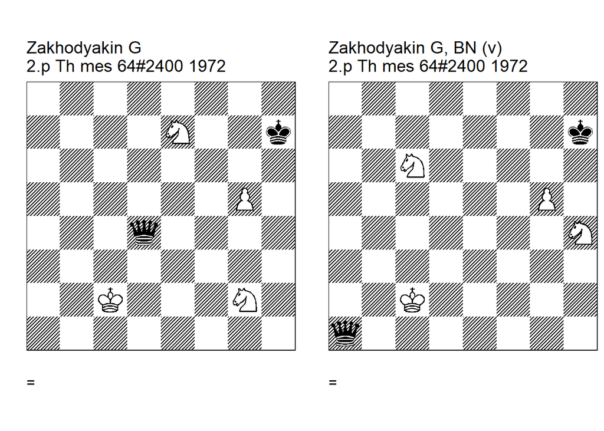

```
Zakhodyakin G
2.p Th mes 64#2400 1972
=3002.10c2h7 cook U2
8/4N2k/8/6P1/3q4/8/2K3N1/8 w - - 0 1
Th mes 64=66 Th mes 64/4-6 also Chess Life & Review#0541 Chess Life & Review=10 Chess
Life & Review/10 1972 (EG#02453). U2: Beasley=J HHdbIII#29359 3-2-2002. 1. g6+ Kh8 (1...
Kg7 2. Nf5+) 2. g7+! Qxg7 3. Nh4! Qh7+ 4. Nhf5! Qh3! 5. Kd2! (5. Nd4! <cook JB> ) 5...
Qf3 6. Kc2! Kh7 7. Kd2 1/2-1/2.


Zakhodyakin G, BN (v)
2.p Th mes 64#2400 1972
=3002.10c2h7 (v)
8/7k/2N5/6P1/7N/8/2K5/q7 w - - 0 1
version: Neuenschwander=B beatochess 09/04/2024. 1. g6+ Kh8 2. g7+ Kxg7 (2... Qxg7 <main>
3. Ne7! Qg4 (3... Qh7+ 4. Nhf5) 4. Nhf5 Qf3 5. Kd2! Qb3 6. Ke2!) 3. Nd4! (3. Nf5+? Kf6 4.
Nfd4 Qa3! 5. Kd2 Kg5!) 3... Kf6 4. Nhf3 1/2-1/2.
```

### +3200.33g1h4 (1967). Version

Date: 2024, April 7

File: Zakhodyakin1967.pgn

The RRvsQ ending seems difficult to fix: the white rooks are simply to strong given the bad position of the black king. In addition to the cook on move 1, there is also the alternative win **4.Rg1** in the main line.

The version shows the theme (luring the black queen to g7 and trapping it) with a white knight and rook.

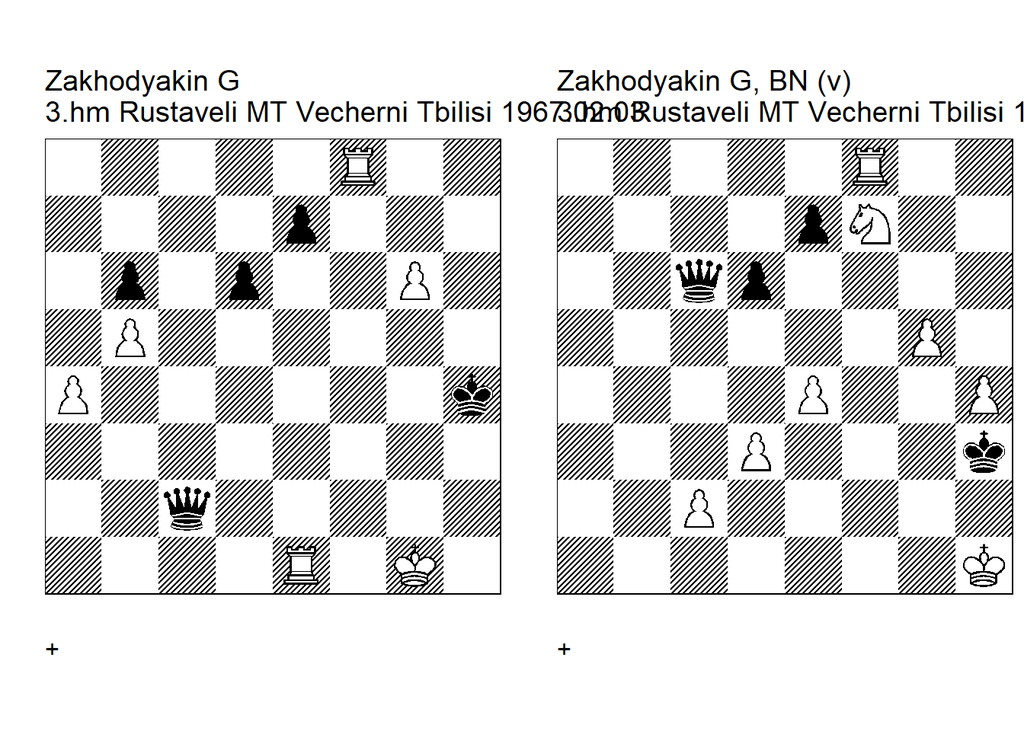

```
Zakhodyakin G
3.hm Rustaveli MT Vecherni Tbilisi 1967.02.03
+3200.33g1h4 cook U1
5R2/4p3/1p1p2P1/1P6/P6k/8/2q5/4R1K1 w - - 0 1
(EG#00396). U1: Beasley=J HHdbIII#33057 3-2-2002 U2: Neuenschwander=B beatochess
07/04/2024. 1. g7 (1. Kh1! <cook JB> 1... Qc3 (1... Qxg6 2. Rh8+) 2. Re2 Qa1+ 3. Kh2)
1... Qg6+ 2. Kh1! (2. Kf2? Qg3+ 3. Kf1 (3. Ke2 Qe5+ 4. Kd3 Qd5+ 5. Ke3 Qe5+ 6. Kf3 Qg3+)
3... Qxg7 4. Rf4+ Kh5)  (2. Kh2? Qg3+ 3. Kh1 Qxe1+) 2... Qxg7 3. Rf4+ Kh5 4. Rf5+ (4. Rg1
<cook BN> 4... Qe5 5. Rfg4 Qd5+ 6. R1g2 Qf3 7. Rg3 Qf1+ 8. Rg1 Qf5 9. Rg5+ Qxg5 10. Rxg5+
Kxg5 11. a5) 4... Kh4 5. Ree5! dxe5 6. Rf2! 1-0.


Zakhodyakin G, BN (v)
3.hm Rustaveli MT Vecherni Tbilisi 1967.02.03
+3101.52h1h3 (v)
5R2/4pN2/2qp4/6P1/4P2P/3P3k/2P5/7K w - - 0 1
version: Neuenschwander=B beatochess 07/04/2024. 1. g6 Qc3 (1... Qxc2 2. Ng5+ Kg3 (2...
Kxh4 3. Rf1!) 3. Rf3+ Kxh4 4. Rf1!)  2. Ng5+ Kxh4 (2... Kg3 3. Rf1) 3. Nf3+ (3. Rf1?
Kh5!) 3... Kh5 (3... Kg3 4. Ng1 Qg7 5. Rf3+! Kh4 6. Kh2) 4. g7! Qxg7 5. Rf5+ Kh6 (5...
Kg4 6. Rg5+) 6. Ne5!! dxe5 (6... Qg3 7. Nf7+ Kh7 8. Rh5+ Kg6 9. Rg5+)  (6... Qg8 7. Nf7+
Kh7 8. Rh5+ Kg6 9. Rg5+)  (6... Kh7 7. Rf7)  (6... e6 7. Nf7+ Kh7 8. Rh5+ Kg8 9. Rg5)
(6... Qh7 7. Rf2)  (6... Qh8 7. Nf7+) 7. Rf2 1-0.
```

### =0002.02c8e8 (1949). Correction

Date: 2024, April 4

File: Zakhodyakin1949.pgn

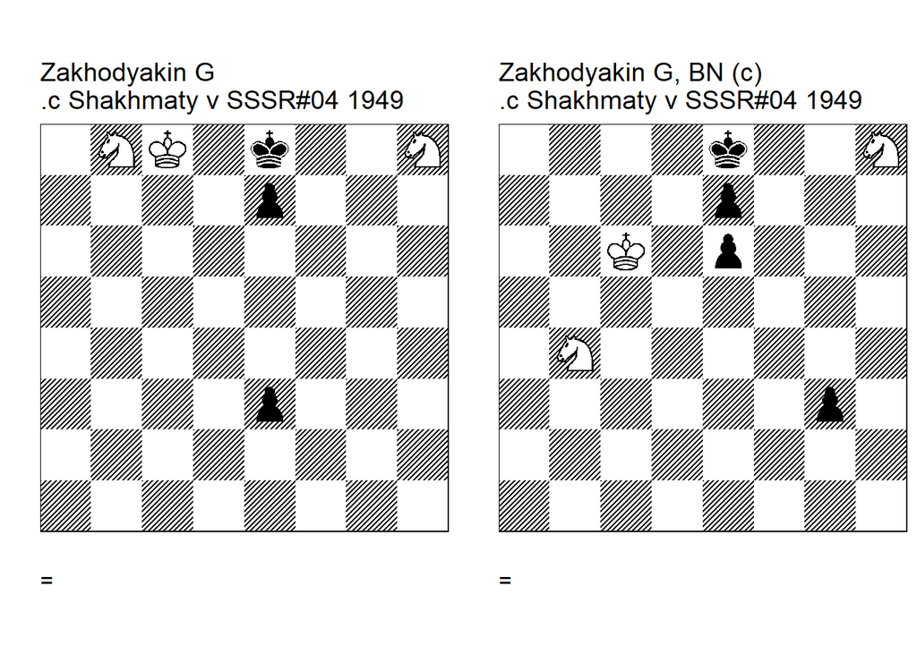

```
Zakhodyakin G
.c Shakhmaty v SSSR#04 1949
=0002.02c8e8 cook U2
1NK1k2N/4p3/8/8/8/4p3/8/8 w - - 0 1
Shakhmaty v SSSR/1. U2: Beasley=J HHdbIII#44615 3-2-2002. 1. Na6! e2 2. Nc7+ Kf8 3. Ne6+
(3. Ng6+! <cook JB> ) 3... Kg8 4. Nf7! e1=Q (4... Kxf7 5. Ng5+) 5. Nfg5! Qd2 <eg> 6. Kc7
Qd5 7. Kb6 Qc4 8. Kb7 1/2-1/2.


Zakhodyakin G, BN (c)
.c Shakhmaty v SSSR#04 1949
=0002.03c6e8
4k2N/4p3/2K1p3/8/1N6/6p1/8/8 w - - 0 1
correction: Neuenschwander=B beatochess 04/04/2024. 1. Na6! g2 2. Nc7+ Kf8 (2... Kd8 3.
Nxe6+ Kc8 4. Ng6 g1=Q 5. Nxe7+ =) 3. Nxe6+ Kg8 4. Nf7! g1=Q 5. Nfg5 1/2-1/2.
```

### =0302.03d1c5 (1948). Correction

Date: 2024, April 4

File: Zakhodyakin1948a.pgn

I needed three more pawns to save this study.

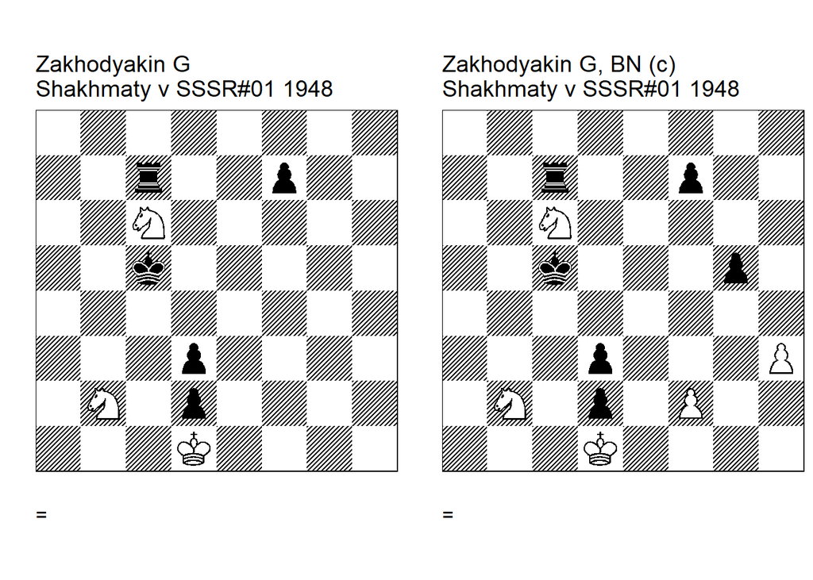

```
Zakhodyakin G
Shakhmaty v SSSR#01 1948
=0302.03d1c5 cook U3
8/2r2p2/2N5/2k5/8/3p4/1N1p4/3K4 w - - 0 1
Shakhmaty v SSSR/1. U3: Shakhmaty v SSSR/3 1957. 1. Ne5 Kd4! 2. Nf3+! (2. Nexd3? Ke3)
2... Kc3! (2... Ke3 3. Nxd2) 3. Na4+ Kb4 4. Nb6! Kc5 5. Na4+ Kb5 6. Nb2! Rc1+ 7. Kxd2
Rc2+ 8. Kxd3 Rxb2 9. Ng5! Rf2 (9... f6 10. Ne4!) (9... f5 10. Ne6!) 10. Ne4! Rf3+ 11. Ke2
Rf4 12. Ke3 Rf1 13. Ke2! Rf4 ( 13... Rg1! <cook> 14. Nd6+ Kc5 15. Nxf7 Rg6 16. Kd3 Kd5
17. Ke3 Re6+ 18. Kd3 Rf6 19. Ng5 Rf5 20. Nh7 Kd6 21. Kd4 Ke7! 22. Ke4 Ke6 23. Kd4 Kf7 24.
Ke4 Kg6) 14. Ke3 1/2-1/2.


Zakhodyakin G, BN (c)
Shakhmaty v SSSR#01 1948
=0302.24d1c5 (c)
8/2r2p2/2N5/2k3p1/8/3p3P/1N1p1P2/3K4 w - - 0 1
correction: Neuenschwander=B beatochess 04/04/2024. 1. Ne5 Kd4 2. Nf3+ Kc3 3. Na4+ Kb4 (
3... Kb3 4. Nb6) 4. Nb6! (4. Nb2? Rc2! 5. Nxd3+ Kc3 6. Ke2 Rc1! 7. Nxd2 Rc2) 4... Kc5 5.
Na4+ Kb5 6. Nb2 Rc1+ 7. Kxd2 Rc2+ 8. Kxd3 Rxb2 9. Nxg5 (9. Ke3 f6) 9... Rxf2 10. Ne4 Rf1
11. Ke2 Rf4 12. Ke3 Rf1 13. Ke2 1/2-1/2.
```

Date: 2024, April 3

File: Zakhodyakin1939.pgn

I offer a correction, since Garcia’s correction does not work due to **1.. Kxc3**.

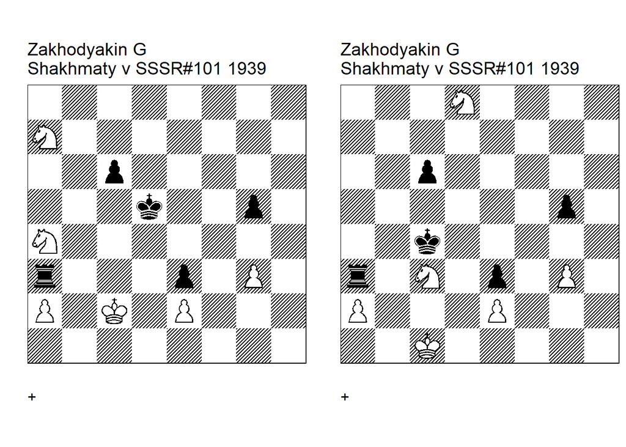

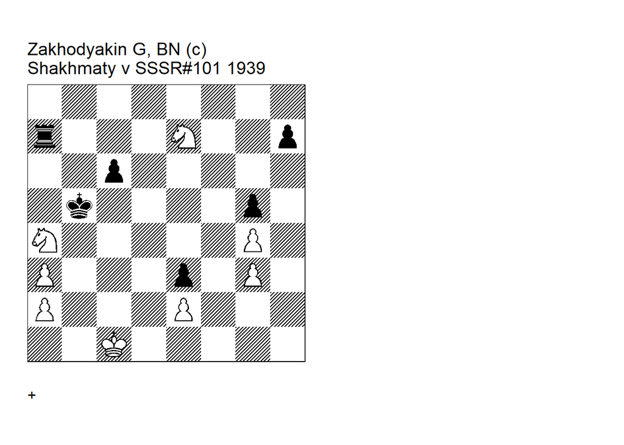

```
Zakhodyakin G
Shakhmaty v SSSR#101 1939
+0302.33c2d5 cook U3
8/N7/2p5/3k2p1/N7/r3p1P1/P1K1P3/8 w - - 0 1
Shakhmaty v SSSR/7. U3: Garcia=M Estudios Artisticos  de Ajedrez - XI-97 2012. 1. Nc3+
Kc4 (1... Kc5! <cook MG> 2. Nc8 Kd4) 2. Nxc6 Rxc3+ 3. Kb2 g4 4. Na5+ Kd4 (4... Kb4 5. a3+
Rxa3 6. Nc6+ Ka4 7. Nd4) 5. Nb3+ Kc4 6. Nc5! Kd4 (6... Kb4 7. Na6+ Kc4 8. Nc7) 7. Ne6+
Kc4 8. Nc7 Kd4 (8... Kb4 <main> 9. Nd5+ Kc4 10. Nxc3) 9. Nb5+ Kc4 10. Nxc3 1-0.


Zakhodyakin G
Shakhmaty v SSSR#101 1939
+0302.33c1c4 cook (c)
3N4/8/2p5/6p1/2k5/r1N1p1P1/P3P3/2K5 w - - 0 1
Shakhmaty v SSSR/7. correction: Garcia=M Estudios Artisticos  de Ajedrez - XI-97 2012.
U3: Neuenschwander=B beatochess 03/04/2024. 1. Nxc6 Rxc3+ (1... Kxc3 -+ <cook BN> ) 2.
Kb2 g4 3. Na5+ Kd4 (3... Kb4 4. a3+ Rxa3 5. Nc6+ Ka4 6. Nd4) 4. Nb3+ Kc4 5. Nc5! Kd4
(5... Kb4 6. Na6+ Kc4 7. Nc7) 6. Ne6+ Kc4 7. Nc7 Kd4 (7... Kb4 <main> 8. Nd5+ Kc4 9.
Nxc3) 8. Nb5+ Kc4 9. Nxc3 1-0.
```

```
Zakhodyakin G, BN (c)
Shakhmaty v SSSR#101 1939
+0302.54c1b5 (c)
8/r3N2p/2p5/1k4p1/N5P1/P3p1P1/P3P3/2K5 w - - 0 1
correction: Neuenschwander=B beatochess 03/04/2024. 1. Nc3+ Kc4 2. Nxc6 Rxa3 3. Kc2!! (3.
Nd1? Rxa2 4. Nxe3+ Kc3 5. Nd5+ Kc4 6. e4 Ra3)  (3. Kb2 Rxc3 4. Ne7 (4. Na5+? Kb4 5. a3+
Rxa3 6. Nc6+ Ka4 7. Nd4 h6) 4... Kd4 5. Nf5+ Kc4)  3... Rxc3+ 4. Kb2 h6 5. Na5+ Kd4 (5...
Kb4 6. a3+! Rxa3 7. Nc6+ Ka4 8. Nd4! ) 6. Nb3+ Kc4 7. Nc5! Kd4 (7... Kb4 8. Na6+ Kc4 9.
Nc7!) 8. Ne6+ Kc4 9. Nc7! Kd4 (9... Kb4 10. Nd5+) 10. Nb5+ 1-0.
```

### +0161.00b3a8 (1933). Version

Date: 2024, March 27

File: Zakhodyakin1933.pgn

In the original study, **5.Nc5** also wins; strictly speaking a cook, although not really an important one. My version has a slightly differen domination theme: both bishops on the fourth rank after 1… Bb4 (variation) and at the end of the study.

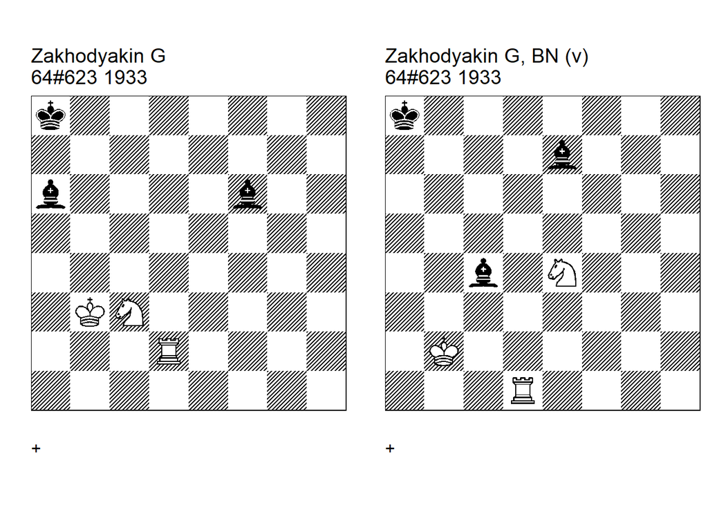

```
Zakhodyakin G
64#623 1933
+0161.00b3a8 cook U2
k7/8/b4b2/8/8/1KN5/3R4/8 w - - 0 1
64=1 64/1. U2: Neuenschwander=B beatochess 27/03/2024. 1. Ne4! (1. Rd6? Bxc3) 1... Be7!
(1... Be5 2. Ra2 Ka7 3. Nc5) 2. Rd7 Bh4 3. Rh7 Be1 4. Rh1 Ba5 5. Ra1 (5. Nc5 <cook BN> )
1-0.


Zakhodyakin G, BN (v)
64#623 1933
+0161.00b3a8 (v)
k7/4b3/8/8/2b1N3/8/1K6/3R4 w - - 0 1
version: Neuenschwander=B beatochess 27/03/2024. 1. Rd7 Bh4 (1... Bb4 2. Rd4) 2. Rh7 Be1
3. Rh1 Bb4 (3... Ba5 4. Ra1 (4. Nc5 <or> ) ) 4. Ra1+ Kb7 5. Ra4 1-0.
```

### =0310.22f6c6 (1931). Correction

Date: 2024, March 26

File: Zakhodyakin1931a.pgn

I managed to save the study with two additional pawns.

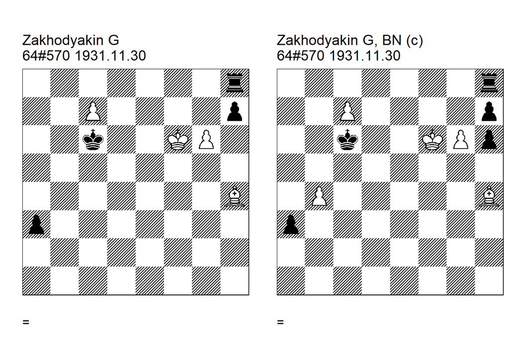

```
Zakhodyakin G
64#570 1931.11.30
=0310.22f6c6 cook U3
7r/2P4p/2k2KP1/8/7B/p7/8/8 w - - 0 1
64=21-22 . U3: 64=12 10-1-1933 U3: Neuenschwander=B beatochess 26/03/2024. 1. g7 a2 (1...
Rc8! <cook> 2. Bg3 a2 3. Be5 h5)  (1... Ra8 <cook BN> 2. Bg3 a2 3. Be5 h5) 2. gxh8=Q
a1=Q+ 3. Kf7 Qxh8 4. Bd8! Kd7 5. c8=Q+! Kxc8 6. Bf6! Qd8 7. Bxd8 Kxd8 8. Kf6 1/2-1/2.


Zakhodyakin G, BN (c)
64#570 1931.11.30
=0310.33f6c6 (c)
7r/2P4p/2k2KPp/8/1P5B/p7/8/8 w - - 0 1
correction: Neuenschwander=B beatochess 26/03/2024. 1. g7 a2 (1... Rc8 2. Bg3 a2 (2... h5
3. Kg5 a2 4. Be5 Re8 5. Kh4 Kb7 6. Kg3) 3. Be5 Kb7 4. Kf5 Re8 5. Kf4! (5. b5? Rxe5+)  (5.
Kg4? Kc6 6. Kf4 h5 7. Kg3 Kd5) 5... h5 6. Kg3 Kb6 (6... Kc6 7. Kh4) 7. Kh3 Kc6 (7... Kb5
8. Kg3 Kxb4 9. Kh4 Kc5 10. Ba1 Kc6 11. Kxh5) 8. Kh4 Kb7 (8... Kd7 9. b5) 9. Kg3) 2.
gxh8=Q a1=Q+ 3. Kf7 Qxh8 4. Bd8 Kd7 5. c8=Q+ Kxc8 6. Bf6 1/2-1/2.
```

### +0031.22b8a6 (1930). Correcction, modifications

Date: 2024, March 24

File: Zakhodyakin1930d.pgn

In addition to Mario’s cook **1.Nd4**, the queen promotion **6.b8=Q** at the end also wins. The second study is a same material correction, whereas studies 3 and 4 are modifications.

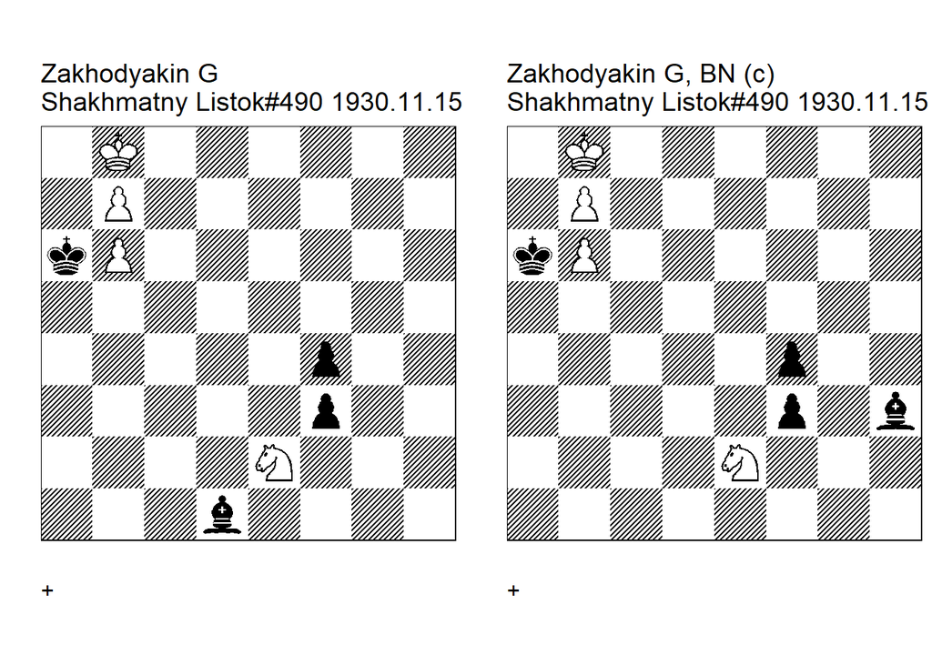

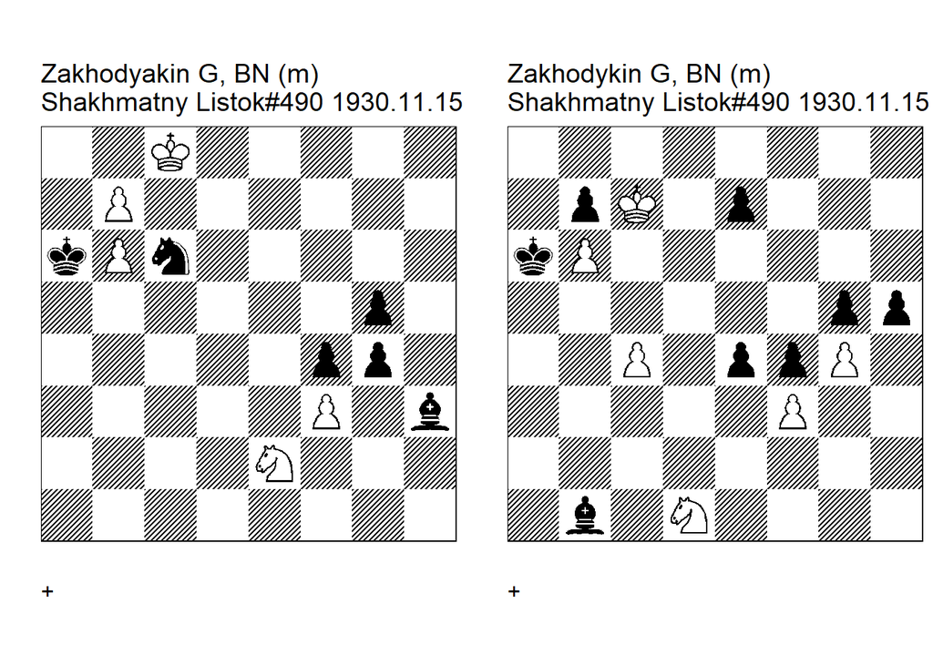

```
Zakhodyakin G
Shakhmatny Listok#490 1930.11.15
+0031.22b8a6 cook U1 U2
1K6/1P6/kP6/8/5p2/5p2/4N3/3b4 w - - 0 1
Shakhmatny Listok=21 . U1: Garcia=M HHdbIV#14207 19-1-2007. U2: Neuenschwander=B
beatochess 27/03/2024. 1. Nc3 (1. Nd4! <cook MG> 1... f2 2. Kc7 f1=Q 3. b8=N+ Ka5 4.
Nbc6+ Ka4 (4... Ka6 5. b7 Qc4 6. b8=N#) 5. b7 Ka3 6. b8=Q Ka2 7. Qb4 Qg2 8. Qe1) 1... f2
2. Kc7 f1=Q 3. b8=N+! Ka5 4. Nc6+ Ka6 5. b7! Qd3 (5... Qb5 6. Nxb5) 6. b8=N# (6. b8=Q
<cook BN> ) 1-0.


Zakhodyakin G, BN (c)
Shakhmatny Listok#490 1930.11.15
+0031.22b8a6 (c)
1K6/1P6/kP6/8/5p2/5p1b/4N3/8 w - - 0 1
correction: Neuenschwander=B beatochess 27/03/2024. 1. Nc3 f2 2. Kc7 f1=Q 3. b8=N+ (3.
b8=Q? Qc4+ 4. Kd6 Qxc3) 3... Ka5 4. Nc6+ Ka6 5. b7 Qd3 6. b8=N# (6. Nd5? Qh7+ 7. Nde7
Qb1)  (6. b8=Q? Qd7#) 1-0.
```

```
Zakhodyakin G, BN (m)
Shakhmatny Listok#490 1930.11.15
+0034.33c8a6 (m)
2K5/1P6/kPn5/6p1/5pp1/5P1b/4N3/8 w - - 0 1
modfication: Neuenschwander=B  beatochess 27/03/2024. 1. Kc7 Nb8 (1... Bg2 2. Nd4 Nxd4 3.
b8=Q +-)  (1... gxf3 2. Kxc6 Bd7+ 3. Kc7 fxe2 4. b8=Q e1=Q 5. Qa8+ Kb5 6. Qd5+ Ka6 7.
Qa2+ Kb5 8. Qb2+ Kc5 9. b7 +-) 2. Kxb8 (2. Nd4 gxf3 3. Nxf3 Bg2)  (2. Nxf4 gxf3 3. Nxh3
g4 4. Kxb8 gxh3 =) 2... gxf3 3. Nc3 (3. Nd4? f2 4. Kc7 f1=Q 5. b8=Q Qc4+ 6. Nc6 Qf7+ 7.
Kd6 Qe6+ 8. Kc5 Qe3+ =) 3... f2 4. Kc7 f1=Q 5. b8=N+ Ka5 6. Nc6+ Ka6 7. b7 Qd3 8. b8=N#
(8. Nd5 Qh7+ 9. Nde7 Qb1 =) 1-0.


Zakhodykin G, BN (m)
Shakhmatny Listok#490 1930.11.15
+0031.46c7a6 (m)
8/1pK1p3/kP6/6pp/2P1ppP1/5P2/8/1b1N4 w - - 0 1
modification: Neuenschwander=B  beatochess 27/03/2024. 1. c5 (1. gxh5? e3)  1... e3 2.
Nc3 e2 3. Nxe2 hxg4 4. c6 gxf3 5. Nc3 f2 6. cxb7 f1=Q 7. b8=N+! Ka5 8. Nc6+ Ka6 9. b7 Qd3
10. b8=N#! 1-0.
```

### +0161.00e1a8 (1930). Comment

Date: 2024, March 23

File: Zakhodyakin1930c.pgn

The reason for the second study is the cook **1.Ne6**. This information is missing in **HHdbVI**.

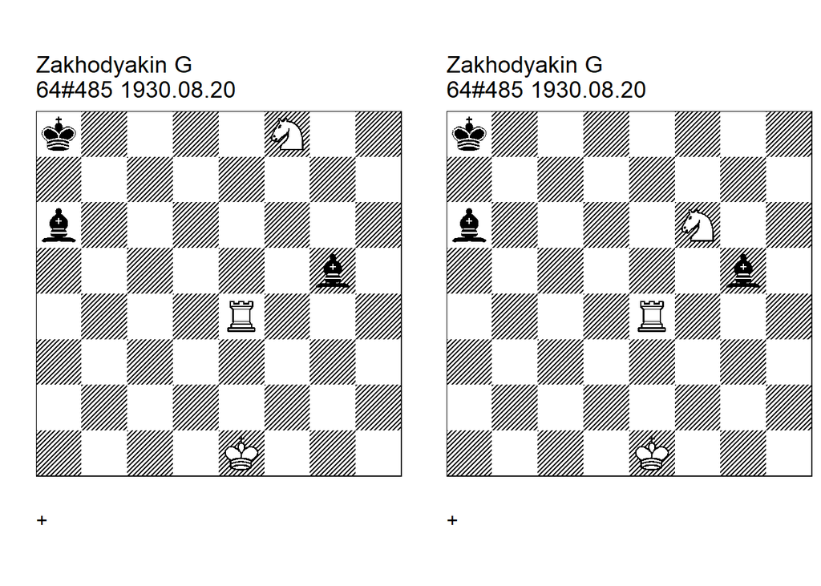

```
Zakhodyakin G
64#485 1930.08.20
+0161.00e1a8 cook U1
k4N2/8/b7/6b1/4R3/8/8/4K3 w - - 0 1
64=22-23. U1: Neuenschwander=B 2024 . 1. Nh7 (1. Ne6!  <cook BN> 1... Bf6 2. Ra4) 1...
Bc1! 2. Kd1 Bb2 (2... Bd3 <main> 3. Re8+ Kb7 4. Kxc1 Bxh7 5. Re7+ Kc6 6. Rxh7) 3. Kc2 Ba1
(3... Bg7 4. Re8+ Ka7 5. Re7+)  (3... Ba3 4. Ra4)  4. Ra4 1-0.


Zakhodyakin G
64#485 1930.08.20
+0161.00e1a8 (v)
k7/8/b4N2/6b1/4R3/8/8/4K3 w - - 0 1
64=22-23 . 1. Nh7 Bc1 2. Kd1 Bb2 (2... Bd3 <main> 3. Re8+ Kb7 4. Kxc1 Bxh7 5. Re7+ Kc6 6.
Rxh7) 3. Kc2 Ba1 (3... Ba3 4. Ra4) (3... Bg7 4. Re8+ Kb7 5. Re7+ Kc6 6. Rxg7) 4. Ra4 1-0.
```

### +0018.01h7f8 (1930). Modification

Date: 2024, March 23

File: Zakhodyakin1930b.pgn

Mario’s attempt to correct the study failed, but Peter succeeded. My version is another correction, a bit more in the light-material spirit of Zakhodaykin’s original.

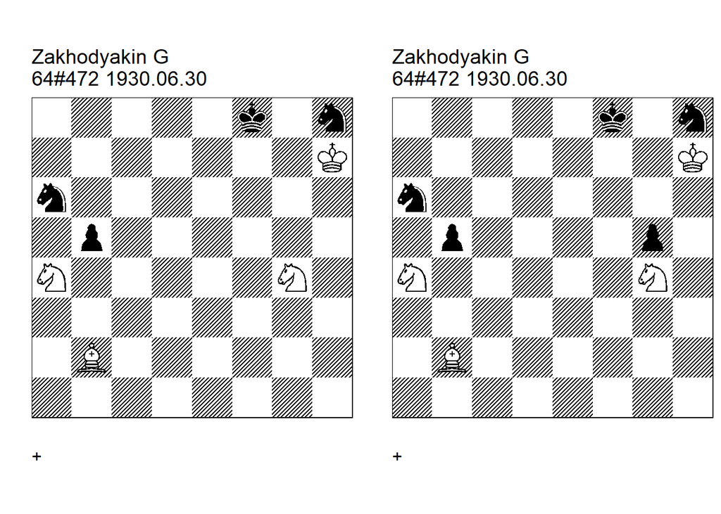

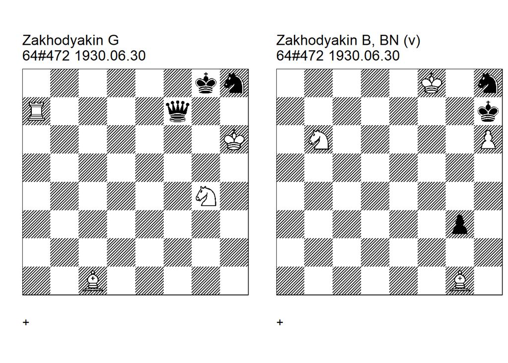

```
Zakhodyakin G
64#472 1930.06.30
+0018.01h7f8 cook U3
5k1n/7K/n7/1p6/N5N1/8/1B6/8 w - - 0 1
64=17-18 . U3: Beasley=J HHdbIII#54385 3-2-2002. 1. Nc5 Nxc5 2. Ba3 Ke8 (2... Kf7! <cook
JB> 3. Bxc5 Ng6 4. Nh6+ Kf6 5. Bd4+ Kg5 6. Nf7+ Kh5)  (2... b4! <cook JB> 3. Bxb4 Kf7) 3.
Bxc5 Nf7 4. Kg6 Nd8 5. Nf6# 1-0.


Zakhodyakin G
64#472 1930.06.30
+0018.02h7f8 cook (c) U2 U3
5k1n/7K/n7/1p4p1/N5N1/8/1B6/8 w - - 0 1
64=17-18 . correction: Garcia=M Estudios Artisticos  de Ajedrez - XI-98 2012. U2 U3:
Van_der_Heijden=H HHdbV#70675 1-2-2014. 1. Nc5 Nxc5 2. Ba3 Ke8 (2... Kf7 3. Bxc5 Ng6 4.
Nh6+ Kf6 5. Bd4+ Ne5 6. Ng4+ Kf5! <cook HH> 7. Nxe5 g4 8. Kh6 g3 9. Kh5 Ke4)  (2... b4 3.
Bxb4 Kf7 4. Bxc5 Ng6 5. Nh6+ Kf6 6. Bd4+ Ne5 7. Ng4+ Kf5 8. Nxe5) 3. Bxc5 Nf7 4. Kg6 (4.
Kg7! <cook HH> )  (4. Kg8! <cook HH> ) 4... Nd8 5. Nf6# 1-0.
```

```
Zakhodyakin G
64#472 1930.06.30
+3114.00h6g8 (c)
6kn/R4q2/7K/8/6N1/8/8/2B5 w - - 0 1
64=17-18 . correction: Krug=P Estudios Artisticos  de Ajedrez - XX-5 2017. 1. Ra8+! (1.
Rxf7? Kxf7! (1... Nxf7+? 2. Kg6 Kf8 3. Ba3+) ) 1... Qf8+ 2. Rxf8+ Kxf8 3. Kh7 Nf7 4. Ba3+
Ke8 5. Kg6 Nd8 (5... Nh8+ 6. Kg7 Nf7 7. Nf6+ Kd8 8. Kxf7) 6. Nf6# 1-0.


Zakhodyakin B, BN (v)
64#472 1930.06.30
+0014.11f8h7 (v)
5K1n/7k/1N5P/8/8/6p1/8/6B1 w - - 0 1
version: Neuenschwander=B beatochess 24/03/2024 1. Nd7! (1. Be3? Ng6+ 2. Kf7 Ne5+ 3. Ke6
Nf3 =)  (1. Nd5? Kxh6 =) 1... Kxh6 (1... Ng6+ 2. Kf7 Nh4 3. Nf6+ Kxh6 4. Be3#) 2. Kg8 Ng6
3. Be3+ Kh5 4. Kf7 Nh4 (4... g2 5. Nf6+ Kh4 6. Kxg6) 5. Nf6# 1-0.
```

### +4001.02h6g8 (1930). Cook/correction/version

Date: 2024, March 22

File: Zakhodyakin1930a.pgn

This is an interesting study. The white knight supports the mating attack by four blocks of the black queen checks. Unfortunately, White also wins after **1.Qc4+!**. The second study ia a same-material correction, and the third one is a version adding one block in the main line and four blocks in the side lines, leading to a total of nin knight blocks.

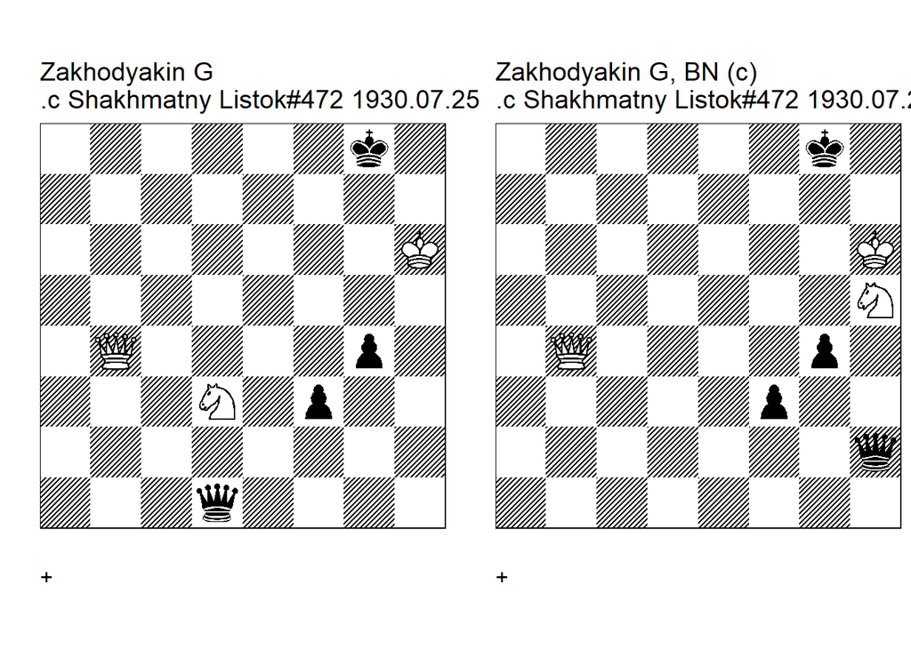

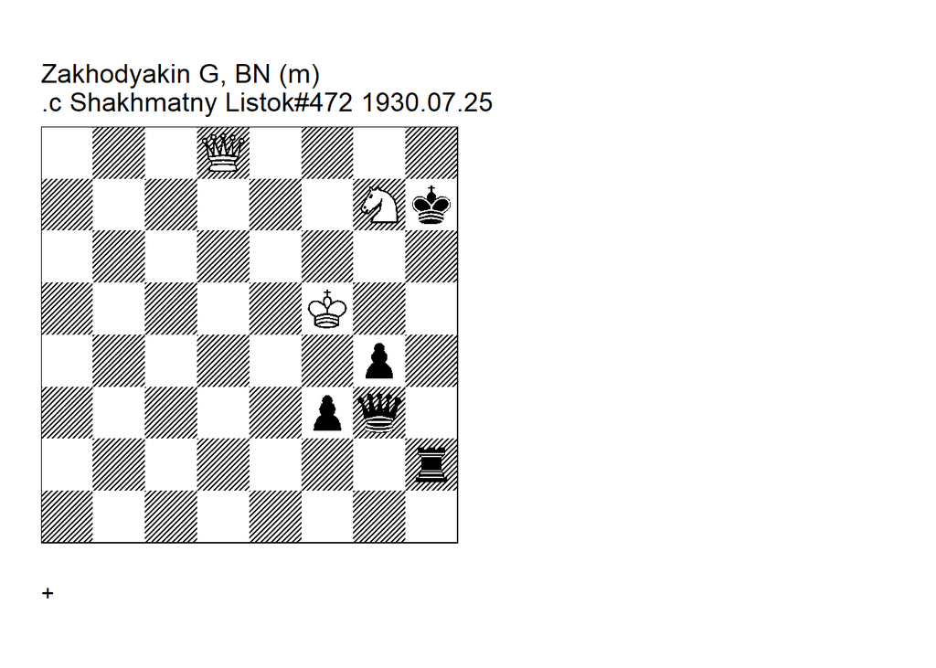

```
Zakhodyakin G
.c Shakhmatny Listok#472 1930.07.25
+4001.02h6g8 cook U1
6k1/8/7K/8/1Q4p1/3N1p2/8/3q4 w - - 0 1
Shakhmatny Listok=14. U1: Neuenschwander=B beatochess 22/03/2024 . 1. Qe7 (1. Qc4+! <cook
BN> 1... Kf8 2. Kg6 Ke8 3. Qc8+ Ke7 4. Qc7+ Ke8 (4... Ke6 5. Nf4#) 5. Kf6 Qa1+ 6. Ne5
Qa6+ 7. Kg7 and Stockfish-16 gives a mate in 17 )  1... Qd2+ 2. Nf4! Qh2+! (2... Qxf4+ 3.
Kg6) 3. Nh3! (3. Kg6? Qc2+) 3... Qd2+ (3... Qxh3+ 4. Kg6) 4. Ng5 Qh2+ <eg> 5. Kg6 Qc2+ 6.
Ne4 Qc6+ 7. Nf6+ 1-0.


Zakhodyakin G, BN (c)
.c Shakhmatny Listok#472 1930.07.25
+4001.02h6g8 (c)
6k1/8/7K/7N/1Q4p1/5p2/7q/8 w - - 0 1
correction: Neuenschwander=B beatochess 22/03/2024. 1. Qe7 Qd2+ 2. Nf4! (2. Kg6? Qc2+ 3.
Kh6 Qc1+ =) 2... Qh2+ 3. Nh3! (3. Kg6? Qc2+ 4. Kf6 Qc6+ 5. Ne6 Qc3+ =) 3... Qd2+ 4. Ng5
(4. Kg6? Qc2+ =) 4... Qh2+ 5. Kg6 Qc2+ 6. Ne4 1-0.
```

```
Zakhodyakin G, BN (m)
.c Shakhmatny Listok#472 1930.07.25
+4301.02f5h7 (m)
3Q4/6Nk/8/5K2/6p1/5pq1/7r/8 w - - 0 1
modification: Neuenschwander=B beatochess 22/03/2024. 1. Qe7 Kg8 (1... Qh4 2. Qf7 Kh8
(2... Qh6 3. Nh5+ Kh8 4. Qe8+ Kh7 5. Qe7+ Kh8 6. Qe5+ Kg8 7. Nf6+ +/-)  3. Qf8+ Kh7 4.
Ne6 Qh5+ 5. Ng5+ (theme) 5... Qxg5+ 6. Kxg5 +-) 2. Kg6 Rh6+ ( 2... Qb8 3. Nf5 (theme)
3... Qb6+ 4. Nd6 Qb1+ 5. Ne4 (theme) 5... Qb6+ 6. Nf6+ (theme) ) 3. Kxh6 Qh2+ 4. Nh5
(theme) 4... Qd2+ 5. Nf4 (theme) 5... Qh2+ 6. Nh3 (theme) 6... Qd2+ 7. Ng5 (theme) 7...
Qh2+ 8. Kg6 Qc2+ 9. Ne4 (theme) 1-0.
```

## Studies by Weenink

In this section, you find a few new cooks, comments, and revisions.

Weenink in HHdbVI

| author | res.gbr.wkbk | comments | year | source |
| --- | --- | --- | --- | --- |
| Weenink, H | +0310.11b4a1 |  | 1911 | Algemeen Handelsblad#101 |
| Weenink, H | +4000.15g3e7 |  | 1913 | Tijdschrift v.d. KNSB#186 |
| Weenink, H | +0004.11e7b1 | cook (s) U2” | 1914 | Tijdschrift v.d. KNSB#193 |
| Weenink, H | +0310.10b2e5 |  | 1917 | Tijdschrift v.d. KNSB#235 |
| Weenink, H | =0400.02c1b3 |  | 1918 | Algemeen Handelsblad |
| Weenink, H | +0130.00h6g8 | (c)” | 1918 | De Telegraaf |
| Weenink, H | +0130.00f5f7 | cook U2” | 1918 | De Telegraaf |
| Weenink, H | +0130.00h6g8 | cook U1” | 1918 | De Telegraaf |
| Weenink, H | +0130.01f5f7 | (c)” | 1918 | De Telegraaf |
| Weenink, H | +0003.21a4a6 |  | 1918 | Op de Hoogte |
| Weenink, H | +0040.32f5d8 | cook U3” | 1918 | Tijdschrift v.d. KNSB#080 |
| Weenink, H | =0010.03f1h1 | cook (v) U1” | 1918 | Tijdschrift v.d. KNSB#240 |
| Weenink, H | =0010.03f1h1 | U1” | 1918 | Tijdschrift v.d. KNSB#240 |
| Weenink, H | =0010.03f1h2 | (c)” | 1918 | Tijdschrift v.d. KNSB#240 |
| Weenink, H | +0020.24a6h1 |  | 1918 | Tijdschrift v.d. KNSB#246 |
| Weenink, H | =0040.02a1e1 |  | 1918 | Tijdschrift v.d. KNSB#254 |
| Weenink, H | +0040.22e1c2 | cook U3” | 1918 | Tijdschrift v.d. KNSB#255 |
| Weenink, H | +0050.01c6e7 | cook U2” | 1918 | Tijdschrift v.d. KNSB#258 |
| Weenink, H | +4007.33e1e4 |  | 1918 | Tijdschrift v.d. KNSB#261 |
| Weenink, H | +0130.11c2g4 | cook U2” | 1919 | Algemeen Handelsblad |
| Weenink, H | +0010.12h1g8 | cook U1” | 1919 | Algemeen Handelsblad |
| Weenink, H | +0110.02d2b1 | (c)” | 1919 | Algemeen Handelsblad |
| Weenink, H | +0110.02d2b1 | cook U1” | 1919 | Algemeen Handelsblad |
| Weenink, H | +0432.00h3h8 | cook U1 U2 U3” | 1919 | Tijdschrift v.d. KNSB#269 |
| Weenink, H | +0040.11h6f6 |  | 1919 | Tijdschrift v.d. KNSB#277 |
| Weenink, H | +0110.03h4h8 |  | 1919 | Tijdschrift v.d. KNSB#278 |
| Weenink, H | +4010.01h7g4 |  | 1920 | De Telegraaf |
| Weenink, H | +0040.12e6a4 |  | 1922 | Magyar Sakkvilag#011 |
| Weenink, H | +0440.44g5b2 | cook U1” | 1922 | ostergotlands Dagblad |
| Weenink, H | +0013.12d2a1 | cook U2” | 1922 | De Oprechte Haarlemsche Courant#097 |
| Weenink, H | +0013.13d2a1 | (c)” | 1922 | De Oprechte Haarlemsche Courant#097 |
| Weenink, H | +0010.11a4b2 |  | 1922 | 6.p Kagan’s Neueste Schachnachrichten#14 |
| Weenink, H | +0000.11d3b4 |  | 1923 | De Oprechte Haarlemsche Courant#112 |
| Weenink, H | +0110.01e6g6 | cook U2” | 1923 | The Chess Amateur#0844 |
| Weenink, H | =0400.12b1c7 | cook U1 U3” | 1923 | The Chess Amateur#0916 |
| Weenink, H | +0000.22f2h4 | (v)” | 1924 | Tijdschrift v.d. KNSB#451 |
| Weenink, H | +0000.22f3g5 |  | 1924 | Tijdschrift v.d. KNSB#451 |
| Weenink, H | +0400.10h1b1 |  | 1925 | Tijdschrift v.d. KNSB#499 |
| Weenink, H | +3101.33h2h5 |  | 1927 | The Chess Amateur#1411 |
| Weenink, H | =0100.14b5g8 |  | 1927 | The Chess Amateur#1463 |
| Weenink, H | +0040.23c7h5 | PH (c)” | 1932 | H.G.M. Weenink#04 |
| Weenink, H | +0040.23c7h5 | cook PH U2” | 1932 | H.G.M. Weenink#04 |

### Weenink +4010.h7g4 (1920). Cook, correction

Date: 2024, May 27

File: Weenink1920.pgn

The cook **1. Qe6+** (leaving to the main variation after a couple of moves) can be avoided by an additional black pawn.

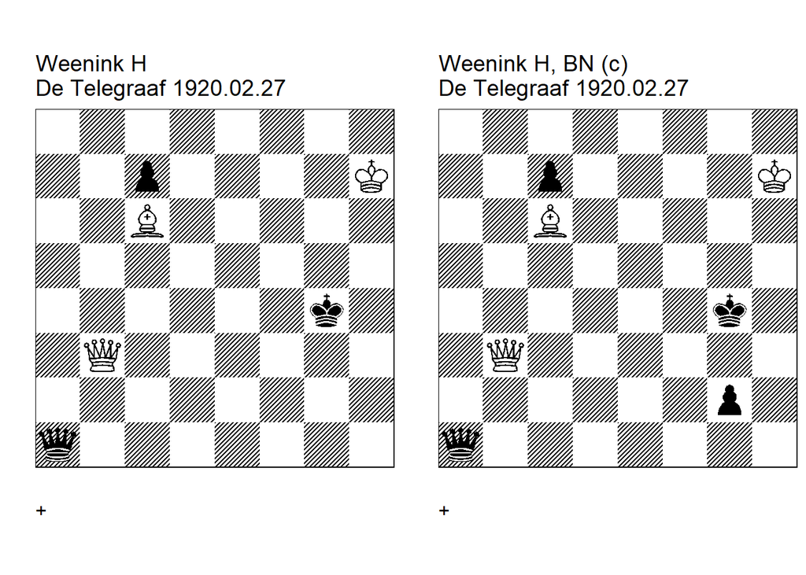

```
Weenink H
De Telegraaf 1920.02.27
+4010.01h7g4 (c)
8/2p4K/2B5/8/6k1/1Q6/8/q7 w - - 0 1
De Telegraaf=10759 U1: Neuenschwander=B beatochess 27/05/2024. 1. Qf3+ (1. Qe6+ <dual BN>
1... Kg5 2. Qg6+ Kf4 3. Qe4+ Kg3 4. Qf3+ leads to the main line ) 1... Kg5 2. Qg3+ Kf5 3.
Qg6+ Kf4 4. Qe4+ Kg3 (4... Kg5 5. Bd7 Qd1 6. Qf5+ Kh4 7. Qh3+ Kg5 8. Qh6#) 5. Qf3+ Kh4 6.
Bd7 Qb1+ 7. Bf5 Qb4 8. Qe3 Qd6 9. Bc8 Qh2 (9... Qf8 10. Qh3+ Kg5 11. Qg4+ Kf6 12. Qf5+
Ke7 13. Qe6+ Kd8 14. Qd7#) 10. Be6 c5 11. Kh6 Qg3 12. Qe4+ 1-0.


Weenink H, BN (c)
De Telegraaf 1920.02.27
+4010.02h7g4 (c)
8/2p4K/2B5/8/6k1/1Q6/6p1/q7 w - - 0 1
correction: Neuenschwander=B beatochess 27/05/2024. 1. Qf3+ (1. Qe6+? Kg3! 2. Qe3+ Kh2!)
1... Kg5 2. Qxg2+ (2. Qg3+ loses time 2... Kf5 3. Qg6+ Kf4 4. Qe4+ Kg5 5. Qxg2+ <=main
line> ) 2... Kf5 3. Qg6+ Kf4 4. Qe4+ Kg3 5. Qf3+ Kh4 6. Bd7! Qb1+ 7. Bf5 Qb4 8. Qe3! Qd6
9. Bc8! Qh2 10. Be6 c5 11. Kh6! 1-0.
```

### Weenink +0004.11e7b1 (1914). Version

Date: 2024, May 25

File: Weenink1914.pgn

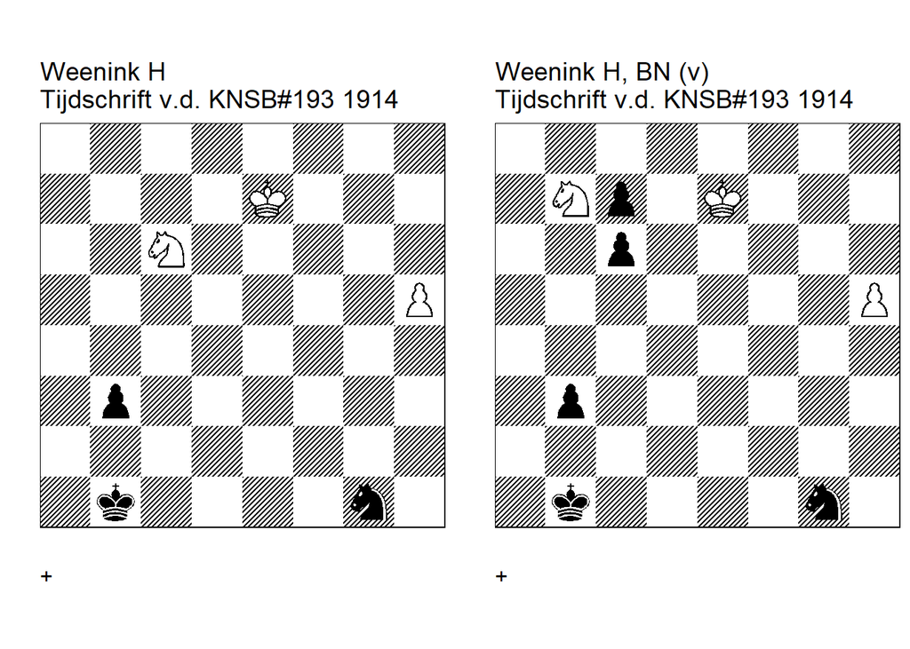

```
Weenink H
Tijdschrift v.d. KNSB#193 1914
+0004.11e7b1 cook (s) U2
8/4K3/2N5/7P/8/1p6/8/1k4n1 w - - 0 1
Tijdschrift v.d. KNSB/10. U2: Garcia=M HHdbV#78646 23-9-2011. 1. Na5! (1. h6? b2 (1...
Kc1? 2. Ne5 Nf3 3. Nd3+ (3. Nc4? Ng5) 3... Kc2 4. h7 Ne5 5. Nxe5 b2 6. Nc4 b1=Q 7. Na3+)
2. Nb4 Nf3 (2... Ka1? 3. h7 b1=Q 4. h8=Q+ Qb2 5. Qa8+ Kb1 6. Qe4+ Ka1 7. Qe1+ Qb1 8. Qe5+
Qb2 9. Qa5+ Kb1 10. Qf5+ Ka1 11. Qf1+ Qb1 12. Qf6+ Qb2 13. Qa6+ Kb1 14. Qf1+ Qc1 15. Qf5+
Ka1 16. Qa5+ Kb2 17. Nd3+)  3. Nd3 (3. h7 Ne5 4. Nd3 (4. Kf6 Ka1 5. h8=Q b1=Q) 4... Nxd3
5. h8=Q Kc2) 3... Ng5 (3... Ne5? 4. Nxb2 Kxb2 5. h7) 4. Kf6 Nh7+ 5. Kg6 Nf8+) 1... b2
(1... Nf3 2. Kf6 Nd2 3. Nxb3) 2. Nc4 Nf3 (2... Nh3 3. Kf6 Nf4 4. h6) 3. Kf6 (3. Nxb2!
<cook MG> 3... Kxb2 4. Kf6) 3... Nh2 (3... Nd2 4. Nxb2 Ne4+ 5. Kg6 Nc5 6. Nd3 Ne6 7. Kf6
Nf8 8. Nc5) 4. Kf5 Nf1 5. Kf4 1-0.


Weenink H, BN (v)
Tijdschrift v.d. KNSB#193 1914
+0004.11e7b1 (v)
8/1Np1K3/2p5/7P/8/1p6/8/1k4n1 w - - 0 1
version: Neuenschwander=B beatochess 24/05/2024 1. Nc5! ( try 1. Na5? b2 2. Nc4 Nf3 3.
Kf6 Nd2 4. Nxb2 Kxb2 5. h6 c5 6. h7 c4 7. h8=Q c3 8. Kf5 Kb3 9. Qb8+ Ka3) 1... b2 (1...
Kc2 2. Nxb3 Kxb3 3. h6 c5 4. h7 c4 5. h8=Q c3 6. Qb8+) 2. Na4 Nf3 3. Kf6! (3. Nxb2? Kxb2
4. Kf6 c5 5. h6 c4 6. h7 c3 7. h8=Q c2) 3... c5 (3... Kc2 4. Nxb2 Kxb2 5. h6 c5 6. h7 c4
7. h8=Q c3 8. Kf5! (8. Qb8+? Kc1) 8... c5 9. Qb8+ <eg> 9... Kc1 10. Ke4 c2 (10... Nd2+
11. Kd3)  11. Kxf3) 4. h6 c4 5. h7 c3 6. h8=Q (6. Nxc3+? Kc2 7. h8=Q Kxc3 8. Qh7 Nd2)
6... c2 7. Nc3+ Kc1 (7... Ka1 8. Qa8#) 8. Qh6+ Nd2 9. Qh1+ 1-0.
```

### Weenink +0440.44g5b2 (1922). Correction

Date: 2024, May 24

File: Weenink1922a.pgn

Note that Garcia’s cook also applies to the main line. Moreover, there is a minor dual (Rf6+ instead of Rg5) on move 13. The additional white pawn on h2, which closes the h-file, saves the study. The other changes in the position are not really important.

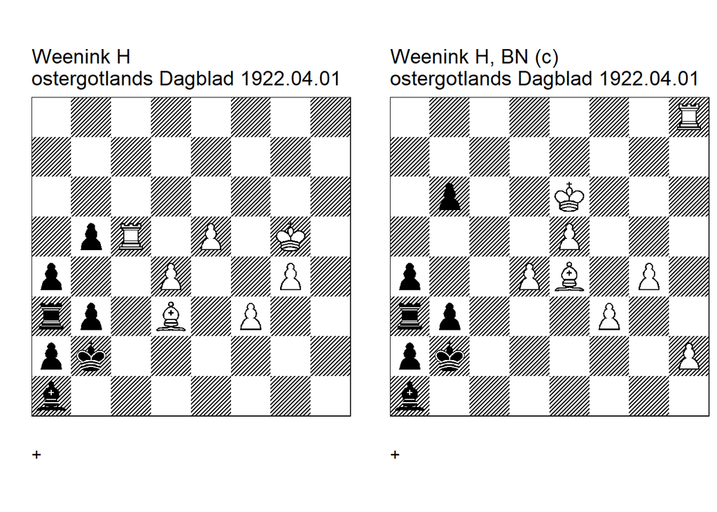

```
Weenink H
ostergotlands Dagblad 1922.04.01
+0440.44g5b2 cook U1
8/8/8/1pR1P1K1/p2P2P1/rp1B1P2/pk6/b7 w - - 0 1
U1: Garcia=M HHdbV#76692 23-9-2011 U1, (U2): Neuenschwander=B beatochess 2024. 1. Bh7!
(1. Bg6! <cook MG> 1... b4 2. Kf5 Kb1 3. Kf4+ Kb2 4. Ke4 Kb1 5. Ke3+ Kb2 6. Kd3 Kb1 7.
Kd2+ Kb2 8. Bf7 Kb1 9. Rc1+ Kb2 10. Rc8 Kb1 11. Bg6+ Kb2 12. Kd3 Kb1 13. Ke3+ Kb2 14.
Rh8) 1... b4 2. Kf5 Kb1 3. Kf4+ Kb2 4. Ke4 Kb1 5. Ke3+ Kb2 6. Kd3 Kb1 7. Kd2+ Kb2 8. Bg8
Kb1 9. Rc1+ Kb2 10. Rc6 Kb1 11. Bh7+ Kb2 12. Rg6 (12. Kd3 <cook BN> 12... Kb1 13. Ke3+
Kb2 14. Rh6) 12... Kb1 13. Rg5+ (13. Rf6+ <minor dual BN> 13... Kb2 14. Rf5) 13... Kb2
14. Rf5 Kb1 15. Rf4+ Kb2 16. Re4 Kb1 17. Re3+ Kb2 18. Rd3 Kb1 19. Rxb3# 1-0.


Weenink H, BN (c)
ostergotlands Dagblad 1922.04.01
+0440.44g5b2 (c)
7R/8/1p2K3/4P3/p2PB1P1/rp3P2/pk5P/b7 w - - 0 1
correction: Neuenshwander=B beatochess 24/05/2024. 1. Rc8 b5 2. Bh7! b4 3. Kf5 Kb1 4.
Kf4+ Kb2 5. Ke4 Kb1 6. Ke3+ Kb2 7. Kd3 Kb1 8. Kd2+ Kb2 9. Bg8! Kb1 10. Rc1+ Kb2 11. Rc6
Kb1 12. Bh7+ Kb2 13. Rg6! Kb1 14. Rg5+ (14. Rf6+ <or>  ) 14... Kb2 15. Rf5 Kb1 16. Rf4+
Kb2 17. Re4 Kb1 18. Re3+ Kb2 19. Rd3 Kb1 20. Rxb3# 1-0.
```

### Weenink +0010.12h1g8 (1919). Correction

Date: 2024, May 22

File: Weenink1919c.pgn

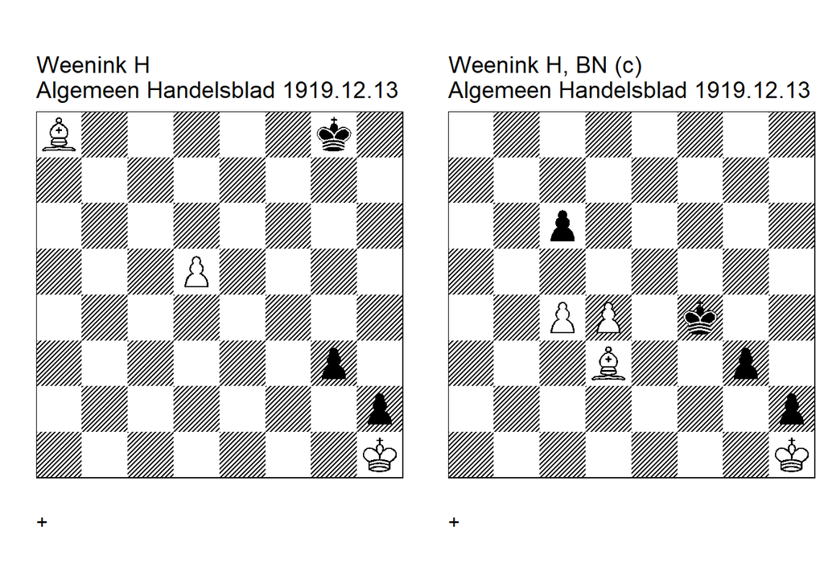

```
Weenink H
Algemeen Handelsblad 1919.12.13
+0010.12h1g8 cook U1
B5k1/8/8/3P4/8/6p1/7p/7K w - - 0 1
Algemeen Handelsblad=29722 . U1: Ulrichsen=J HHdbIII#60326 13-2-2003. 1. Bb7 (1. Bc6!
<cook JU> ) 1... Kf7 2. Ba6 (2. Bc8 <or> 2... Kf6 3. Bg4 Ke5 4. Bf3) 2... Kf6 3. Be2 (3.
Bd3? Ke5 4. Be4? Kxe4 5. d6 Kf3) 3... Ke5 4. Bf3 Kf4 5. Kg2 h1=Q+ 6. Kxh1 Kxf3 7. Kg1
1-0.


Weenink H, BN (c)
Algemeen Handelsblad 1919.12.13
+0010.23h1f4 (c)
8/8/2p5/8/2PP1k2/3B2p1/7p/7K w - - 0 1
correction: Neuenschwander=B beatochess 22/05/2024.c 1. Bf1! (1. d5? cxd5 2. cxd5 Ke5 3.
Bc4 (3. Be4? Kxe4 4. d6 Kf3 5. d7 Kf2 6. d8=Q g2+ 7. Kxh2 g1=Q+ 8. Kh3 Qg3#) 3... Kd6)
1... Ke4 2. d5 cxd5 3. Bg2+ (3. c5 Ke5) 3... Kf4 4. cxd5 (4. Bxd5 Ke5 5. Kg2 Kd4 6. Kxg3
h1=Q 7. Bxh1 Kxc4) 4... Ke5 5. Bf3 Kf4 6. Kg2 h1=Q+ 7. Kxh1 Kxf3 8. Kg1 1-0.
```

### Weenink +0110.02d2b1 (1919). Correction

Date: 2024, May 18

File: Weenink1919b.pgn

Simply moving the rook to h4 (or any square between the fourth and last rank) corrects the study, as correctly noted by Rueb. An additional move is possible, as shown in my correction; here, however, note that the rook cannot be on h4 due to 1. Bc4 b2! 2. Bxa2 Kxa2 3. Ra4+ Kb3.

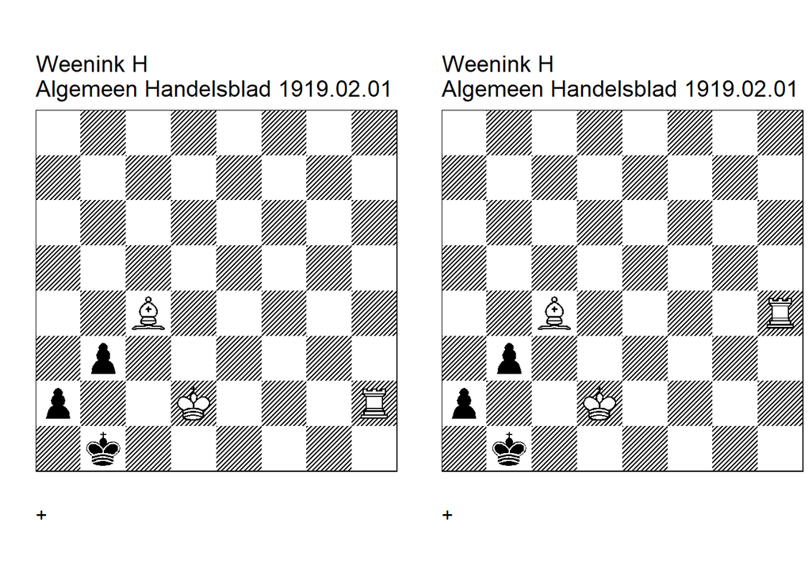

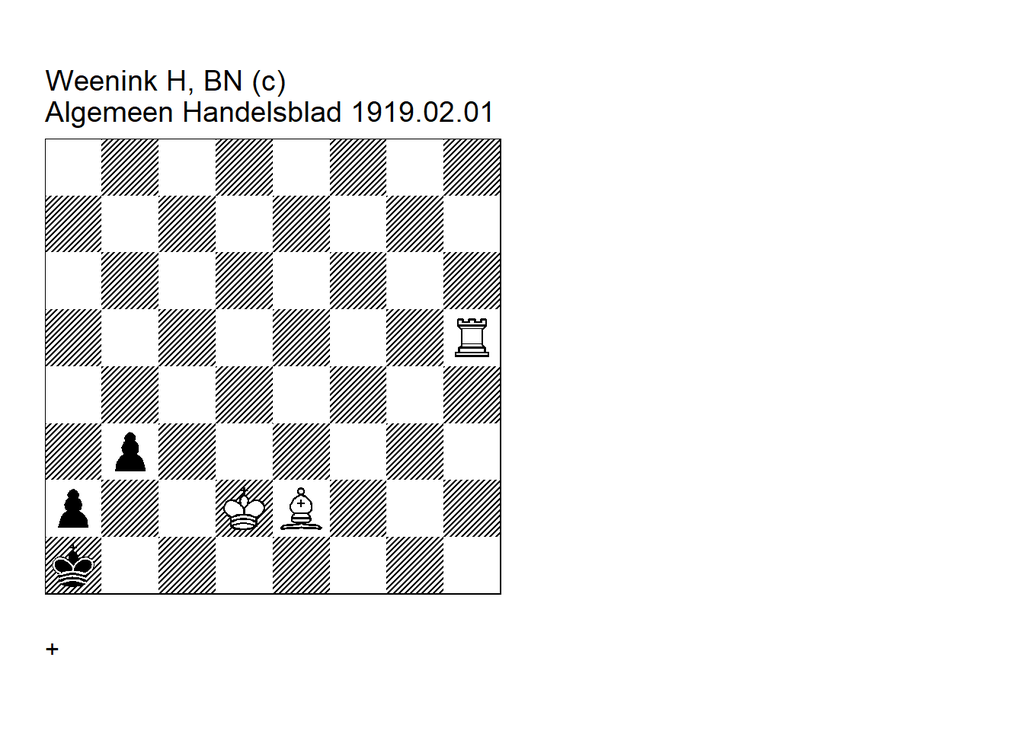

```
Weenink H
Algemeen Handelsblad 1919.02.01
+0110.02d2b1 cook U1
8/8/8/8/2B5/1p6/p2K3R/1k6 w - - 0 1
Algemeen Handelsblad=29409 . U1: Tijdschrift v.d. KNSB/4 1926. 1. Rh1+ (1. Kd1! <cook>
1... b2 2. Rh1 a1=Q (2... Ka1 3. Bxa2 Kxa2 4. Kc2) 3. Kd2#)  1... Kb2 2. Rh3 a1=Q (2...
a1=N 3. Bd5 Ka2 4. Kc1 Ka3 5. Bxb3 Nxb3+ 6. Kc2) 3. Rxb3+ Ka2 4. Kc2 Qd4 5. Rc3+ Ka1 6.
Ra3# 1-0.


Weenink H
Algemeen Handelsblad 1919.02.01
+0110.02d2b1 (c)
8/8/8/8/2B4R/1p6/p2K4/1k6 w - - 0 1
Algemeen Handelsblad=29409 . correction: Rueb=A H.G.M. Weenink#17 1932. 1. Rh1+ Kb2 2.
Rh3 a1=Q 3. Rxb3+ Ka2 4. Kc2 Qd4 5. Rc3+ 1-0.
```

```
Weenink H, BN (c)
Algemeen Handelsblad 1919.02.01
+0110.02d2a1 (c)
8/8/8/7R/8/1p6/p2KB3/k7 w - - 0 1
correction: Neuenschwander=B beatochess 18/05/2024. 1. Bc4 Kb1 (1... b2 2. Bxa2 Kxa2 3.
Ra5+ Kb3 4. Rb5+) 2. Rh1+ Kb2 3. Rh3 a1=Q 4. Rxb3+ Ka2 5. Kc2 Qd4 6. Rc3+ 1-0.
```

### Weenink +0130.11c2g4 (1919). Correction (twin)

Date: 2024, May 17

File: Weenink1919a.pgn

The cooks on move 2 are serious. On the other hand, the cook on move 11 is less relevant. The position after **4. h7 Bh8** can be won in various move orders, but the idea is the same (zugzwang). The study can be saved by getting rid of the cook on move 2 and stop the main line when the white pawn reaches h7.

The version is a twin study which has considerable more content than Weenink’s original study.

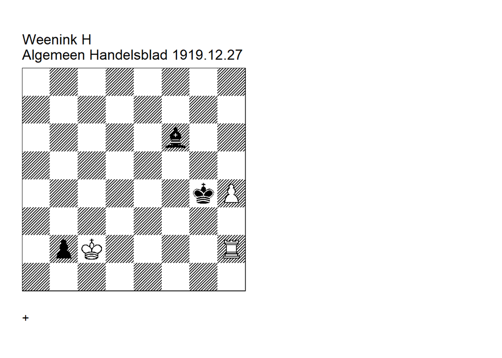

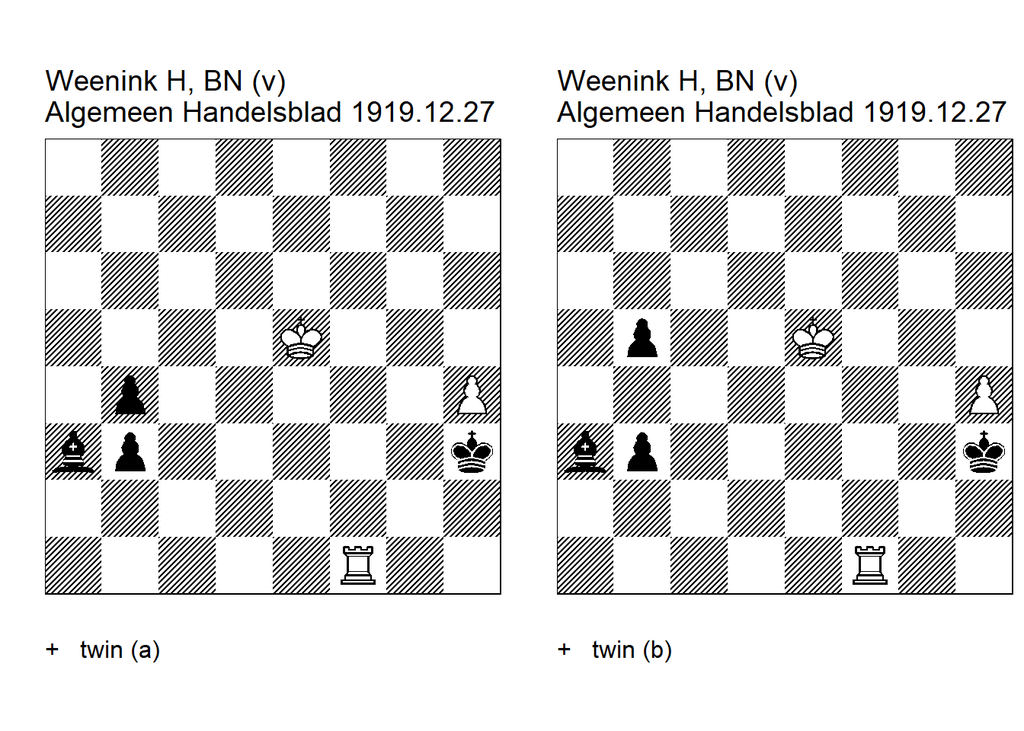

```
Weenink H
Algemeen Handelsblad 1919.12.27
+0130.11c2g4 cook U2
8/8/5b2/8/6kP/8/1pK4R/8 w - - 0 1
Algemeen Handelsblad=29735 . U2: Ulrichsen=J HHdbIII#60327 13-2-2003 U2: Haworth=G
Bleicher=E  HHdbV#77521 9-12-2009. 1. h5 Be5 (1... Kg3 2. Rh1 Kg2 3. Re1 Kg3 4. Re6) 2.
Rh1 (2. Re2! <cook GH/EB> )  (2. Rd2! <cook GH/EB> ) 2... Kg5 3. h6 Kg6 4. h7 Bh8 5. Kb1
Kg5 6. Rh2! Kg6 7. Ka2 Kf7 (7... Kg5 8. Rxb2) 8. Rg2 Bg7 9. Kb1 Kf8 10. Rf2+ Ke7 11. Rh2
(11. Rxb2! <cook JU> )  11... Bh8 12. Rg2 Kf7 13. Rg8 1-0.
```

```
Weenink H, BN (v)
Algemeen Handelsblad 1919.12.27
+0130.12e5h3 (v) TW
8/8/8/4K3/1p5P/bp5k/8/5R2 w - - 0 1
version: TW Neuenschwander=B beatochess 17/5/2024. 1. Rh1+! (1. h5? Bb2+ 2. Kf5 (2. Ke4
Bg7! 3. Rh1+ Kg2!) 2... Bc3! 3. h6 b2! (3... Kg2? 4. Rb1! b2 5. Ke4!) 4. h7 Kg2! 5. Rb1
Kf3) 1... Kg4 2. h5 Bb2+ 3. Ke4 Kg5 4. h6 Kg6 5. h7 Bh8 6. Kd3 b2 7. Kc2 b3+ 8. Kb1 <eg<
8... Kg5 9. Rh3 Kg6 10. Rh2 Kg5 (10... Kf7 11. Rg2 Bg7 12. Rg3) 11. Rxb2 Kg6 12. Rh2 Kg5
13. Rh1 Kg6 14. Rh3 b2 15. Rh2 Kf7 16. Rg2 1-0.


Weenink H, BN (v)
Algemeen Handelsblad 1919.12.27
+0130.12e5h3 (v) TW
8/8/8/1p2K3/7P/bp5k/8/5R2 w - - 0 1
version: TW Neuenschwander=B beatochess 17/5/2024. 1. h5! (1. Rh1+? Kg3! ( 1... Kg4? 2.
h5 Bf8 3. h6) 2. h5 Bf8! 3. h6 Kg2!) 1... Bb2+ (1... b2 2. Rb1) 2. Kf5! (2. Ke4? Bg7!)
2... Bh8 (2... Kg2 3. Rb1!)  (2... Bg7 3. Rf3+) 3. Rf3+! (3. h6? b2) 1-0.
```

### Weenink +0050.01c6e7 (1918). Correction

Date: 2024, May 15

File: Weenink1918c.pgn

In Weenink’s original study, various first moves lead to a win. The key of the study is to keep black king on the last rank (or the h-file), which is shown in the correction.

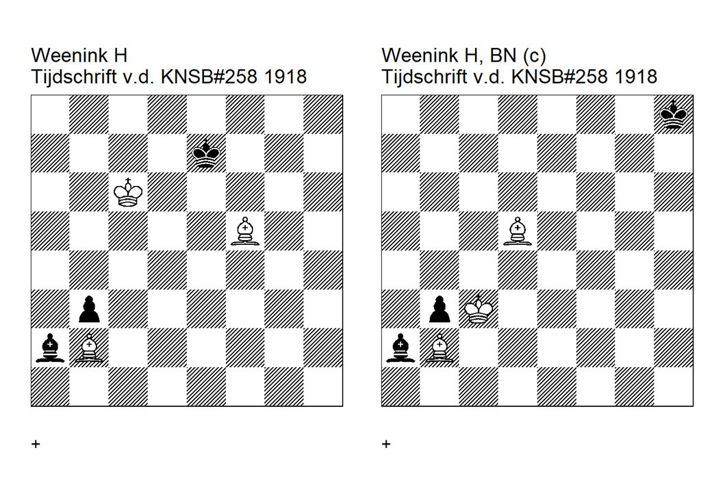

```
Weenink H
Tijdschrift v.d. KNSB#258 1918
+0050.01c6e7 cook U2
8/4k3/2K5/5B2/8/1p6/bB6/8 w - - 0 1
Tijdschrift v.d. KNSB/10. U2: Ulrichsen=J HHdbIII#60576 13-2-2003. U1: Neuenschwander=B
beatochess 2024. 1. Kc7 (1. Kc5 /Kd5/Be4/Bd3/Bg6/Bh7 <cook BN> ) 1... Ke8 2. Kd6 Kf7 3.
Kd7 Kf8 4. Bg6 Kg8 5. Ke6 Kf8 6. Bf7 Bb1 7. Kf6 ( 7. Bh8! <cook JU> ) 7... Bf5 8. Ba3#
1-0.


Weenink H, BN (c)
Tijdschrift v.d. KNSB#258 1918
+0050.01c3h8 (c)
7k/8/8/3B4/8/1pK5/bB6/8 w - - 0 1
correction: Neuenschwander=B beatochess 15/5/2024. 1. Kd3+! Kh7 2. Be4+ Kh6 ( 2... Kg8 3.
Kd4 Kf7 4. Kd5 Ke7 5. Bf5 Kd8 6. Kc6) 3. Ke3 (3. Ke2 <or> ) 3... Kg5 4. Kf3 1-0.
```

### Weenink +0040.22e1c2 (1918). Correction

Date: 2024, May 14

File: Weenink1918b.pgn

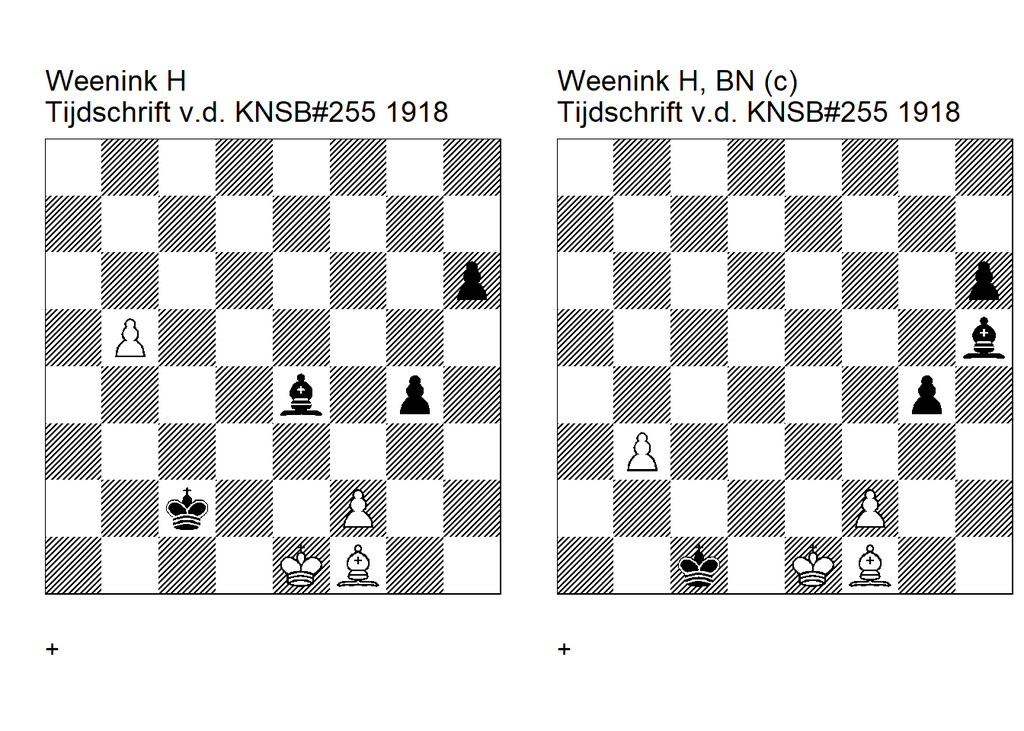

```
Weenink H
Tijdschrift v.d. KNSB#255 1918
+0040.22e1c2 cook U3
8/8/7p/1P6/4b1p1/8/2k2P2/4KB2 w - - 0 1
Tijdschrift v.d. KNSB/7. U3: (HHdbII#06604 2000). 1. b6 Bb7 (1... h5 2. Ba6 h4 3. b7 Bxb7
4. Bxb7 g3 (4... Kd3! <cook> 5. Bc6 Kd4 6. Ke2 Ke5 7. Ke3 Kf5 8. Bd7+ (8. Be4+ Ke5 9. Bc2
Kf6 10. Bd1 Kf5 11. Be2 Kg5 12. Ke4 h3! 13. Bf1 g3 14. f4+ Kh4) 8... Kg5 9. Ke4 Kh5 10.
Kf4 g3) 5. f4 h3 6. Kf1) 2. Bg2! Bxg2 3. f4! g3 (3... gxf3 <main> 4. Kf2!)  (3... h5
<main> 4. Kf2 Bd5 5. Kg3 ) 4. f5 h5 5. f6 h4 6. f7 h3 7. f8=Q h2 <eg> 8. Qf5+ Kb2 9. Qe5+
Kb1 10. Qb5+ Ka1 11. Qa5+ Kb1 12. Qb4+ Ka1 13. Qd4+ Kb1 14. Qd1+ Kb2 15. Qd2+ Kb1 16.
Qxg2 1-0.


Weenink H, BN (c)
Tijdschrift v.d. KNSB#255 1918
+0040.22e1c1 (c)
8/8/7p/7b/6p1/1P6/5P2/2k1KB2 w - - 0 1
correction: Neuenschwander=B beatochess 14/5/2024. 1. b4 Bg6 2. b5 Be4 3. b6 Bb7 4. Bg2!
Bxg2 5. f4 g3 (5... h5 6. Kf2) 6. f5 h5 7. f6 h4 8. f7 h3 9. f8=Q 1-0.
```

### Weenink +0040.32f5d8 (1918). Correction

Date: 2024, May 13

File: Weenink1918a.pgn

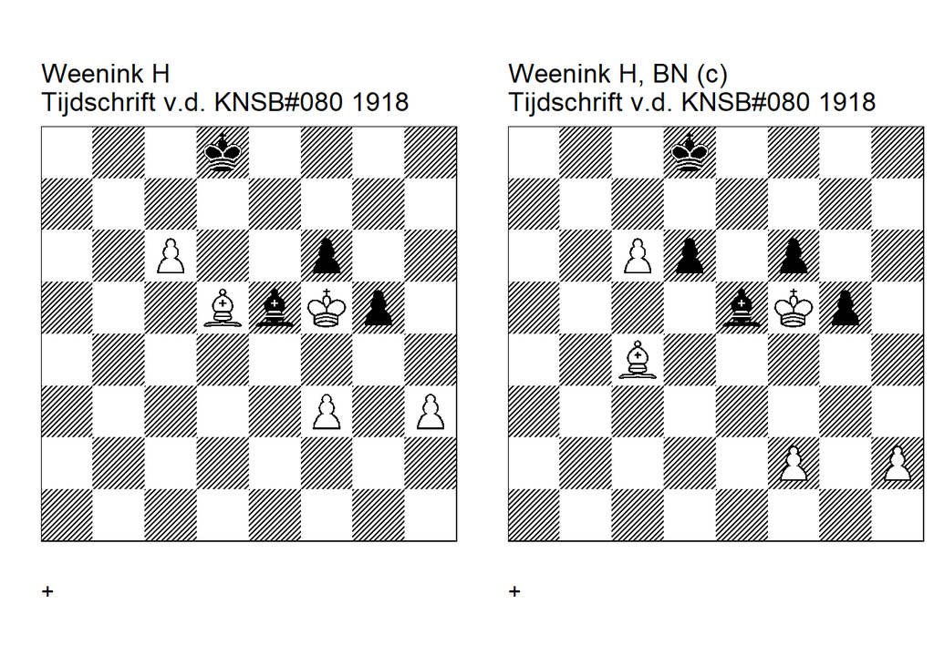

```
Weenink H
Tijdschrift v.d. KNSB#080 1918
+0040.32f5d8 cook U3
3k4/8/2P2p2/3BbKp1/8/5P1P/8/8 w - - 0 1
Tijdschrift v.d. KNSB/2. U3: Garcia=M HHdbV#77762 23-9-2011. Comment: Neuenschwander=B
(move 6). 1. f4! gxf4 (1... Bc3 2. fxg5 fxg5 3. Kxg5 Ke7 4. h4 Bf6+ 5. Kg4 Be5 6. Kf5 (6.
h5? Kf6) 6... Bg3 7. h5 Kf8 8. h6 Bc7 9. Kg6)  (1... Bc7 2. fxg5 fxg5 3. Kxg5 Ke7 4. h4
Be5 (4... Kd6!   <cook MG> ) 5. h5 )  (1... Bxf4 2. h4 Be5 (2... Bc7 3. h5 Ke7 4. h6 Kf8
5. Kxf6)  (2... Bd2 3. h5 g4 4. Kxf6) 3. h5 Ke7 4. h6 Kf8 5. Kg6 f5 6. Kxf5 Bc7 7. Kg6)
2. h4 Ke7 3. Kg6 (3. h5? f3 4. Bxf3 Kf7) 3... Kf8 4. Kh7! (4. h5? f3 5. h6 f2 6. h7 f1=Q
7. h8=Q+ Ke7) 4... f3! 5. Bxf3 f5 <eg> 6. h5 (6. Bd5 also wins ) 6... f4 7. h6 Kf7 8.
Bd5+ Kf8 9. Kg6 f3 10. h7 f2 (10... Ke7 11. Bxf3) 11. h8=Q+ (11. Bg2? Ke7) 11... Bxh8 12.
c7 f1=Q 13. c8=Q+ Ke7 14. Qc7+ Ke8 15. Bc6+ Kf8 <eg> 16. Qd8# 1-0.


Weenink H, BN (c)
Tijdschrift v.d. KNSB#080 1918
+0040.33f5d8
3k4/8/2Pp1p2/4bKp1/2B5/8/5P1P/8 w - - 0 1
correction: Neuenschwander beatochess 13/5/2024. 1. f4! gxf4 (1... Bxf4 2. h4 d5 3. Bxd5
Ke7 4. h5) 2. h4 (2. Bd5? f3 3. Bxf3 Bxh2) 2... d5 3. Bxd5 (3. h5? Ke7 4. h6 Kf8 5. Bxd5
f3 6. Bxf3 Kg8) 3... Ke7 4. Kg6! (4. h5 Kf8 5. h6 f3 6. Bxf3 Kg8) 4... Kf8 5. Kh7! f5
(5... f3 6. Bxf3 f5 7. h5 ( <or> 7. Bd5) ) 6. h5! (6. Bf3? Kf7 7. h5 Kf6 8. h6 Kg5) 6...
f3 7. Bxf3 Kf7 8. h6! (8. Bd5+? Kf6 9. h6 Kg5) 8... Kf6 (8... Bc7 9. Bd5+ Kf6 (9... Kf8
10. Kg6) 10. Kg8) 9. Kg8! 1-0.
```

## Shakhmatny Listok studies

### Videnkin =0044.21b4e5 (1930). Correction

Date: 2024, June 5

File: Videnkin1930.pgn

With the bishop on f6 instead of g7 in the main line, the cook can be avoided. This is used in the correction.

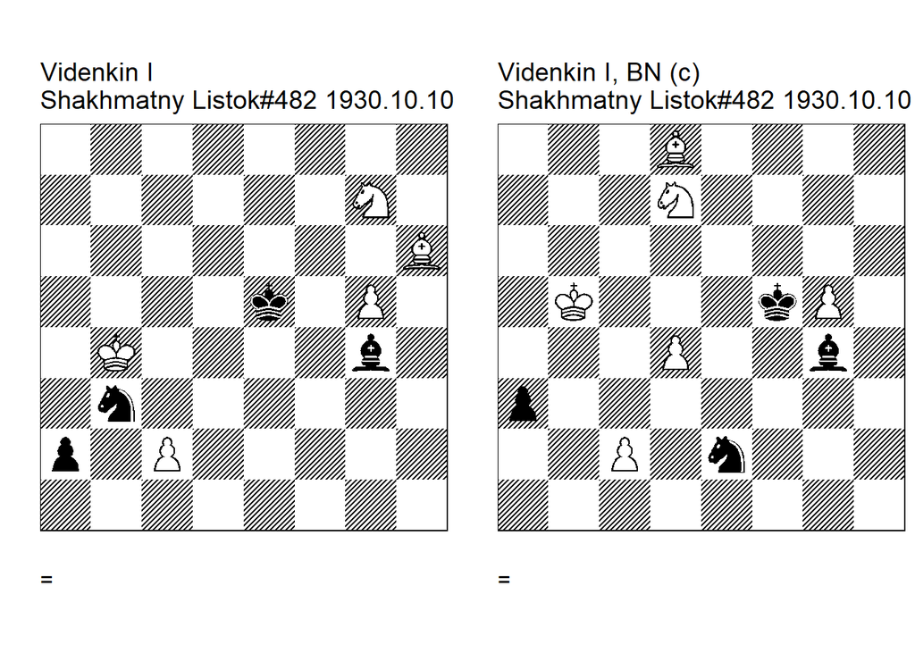

```
Videnkin I
Shakhmatny Listok#482 1930.10.10
=0044.21b4e5 cook
8/6N1/7B/4k1P1/1K4b1/1n6/p1P5/8 w - - 0 1
Shakhmatny Listok=19 U3: Neuenschwander=B beatochess 05/06/2024 . 1. Nf5 Kxf5 2. Bg7 a1=Q
(2... Kg6 3. Kxb3 Be6+ 4. Kb2)  (2... Nc1! <cook BN> 3. Ka3 Kg6! (3... Kxg5? 4. Kb2) 4.
Bh8 Be6) 3. Bxa1 Nxa1 4. Kc3 Bd1! 5. g6! Kxg6 6. Kb2 Nxc2 7. Kc1! Ne3 8. Kd2 1/2-1/2.


Videnkin I, BN (c)
Shakhmatny Listok#482 1930.10.10
=0044.31b5f5 (c)
3B4/3N4/8/1K3kP1/3P2b1/p7/2P1n3/8 w - - 0 1
correction: Neuenschwander=B beatochess 05/06/2024. 1. Nc5 (1. Bf6? Nc3+ 2. Kb4 a2) 1...
Nxd4+ 2. Kb4 a2 3. Nb3 Nxb3 4. Bf6 a1=Q (4... Nc1 5. Ka3 Kg6 6. Kb2 Be6 7. Kxc1) 5. Bxa1
Nxa1 6. Kc3 Bd1 7. g6! Kxg6 8. Kb2 Nxc2 9. Kc1 Ne3 10. Kd2 1/2-1/2.
```

File: Korolkov1929.pgn

**1. Qg4** is a dual in Korolkov’s study because the probably intended **1… Bc2** is not sufficient for a Black advantage. Adding a black pawn on a4 is a simple correction.

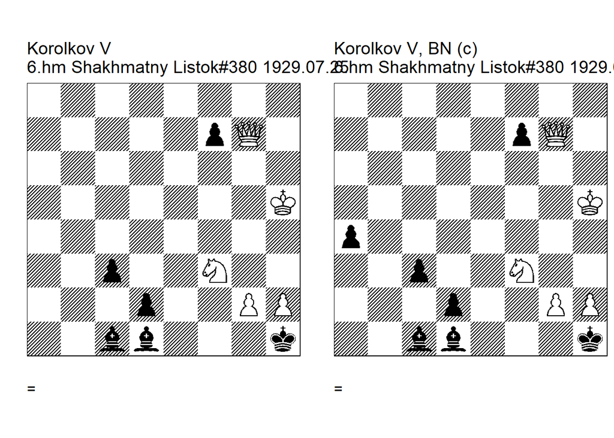

```
Korolkov V
6.hm Shakhmatny Listok#380 1929.07.25
=1061.23h5h1 cook U1
8/5pQ1/8/7K/8/2p2N2/3p2PP/2bb3k w - - 0 1
Shakhmatny Listok=14. U1: Neuenschwander=B 20/05/2024 . 1. Qg3 (1. Qg4! <cook BN> 1...
Bc2 (1... c2 <=main> 2. h4 Bxf3 3. Qxf3 d1=Q 4. g4+ Qxf3) 2. h4 Bg6+ 3. Kh6 d1=Q+ 4. Kg7
Bf5 5. Qg3 Bf4 6. Qxf4  leads to a roughly equal position (SF-16) ) 1... c2 2. h4! Bxf3+
3. Qxf3! (3. gxf3? d1=Q 4. Qh3+ Kg1) 3... d1=Q (3... d1=R 4. g4+ Kg1 5. Qg3+ Kf1 6. Qf3+
Ke1 7. Qe4+)  (3... Bb2 4. Qf1+ Kh2 5. Qf4+ Kg1 6. Qxd2 c1=Q 7. Qxc1+ Bxc1 8. g4 Bb2 9.
g5 Bg7! 10. g6 f6 11. Kg4 Kf2 12. Kf5 Kg3 13. h5) 4. g4+! Qxf3 (4... Kg1 5. Qg2+ Kxg2 )
1/2-1/2.


Korolkov V, BN (c)
6.hm Shakhmatny Listok#380 1929.07.25
=1061.24h4h1 (c)
8/5pQ1/8/7K/p7/2p2N2/3p2PP/2bb3k w - - 0 1
correction Neuenschwander=B beatochess 20/05/2024. 1. Qg3 c2 2. h4 Bxf3+ 3. Qxf3 d1=Q 4.
g4+ Qxf3 1/2-1/2.
```

File: Korolkov1930.pgn

At the end Black has a clear advantage after **7…. Rh2+! Kxh2 8. Bxa8**.

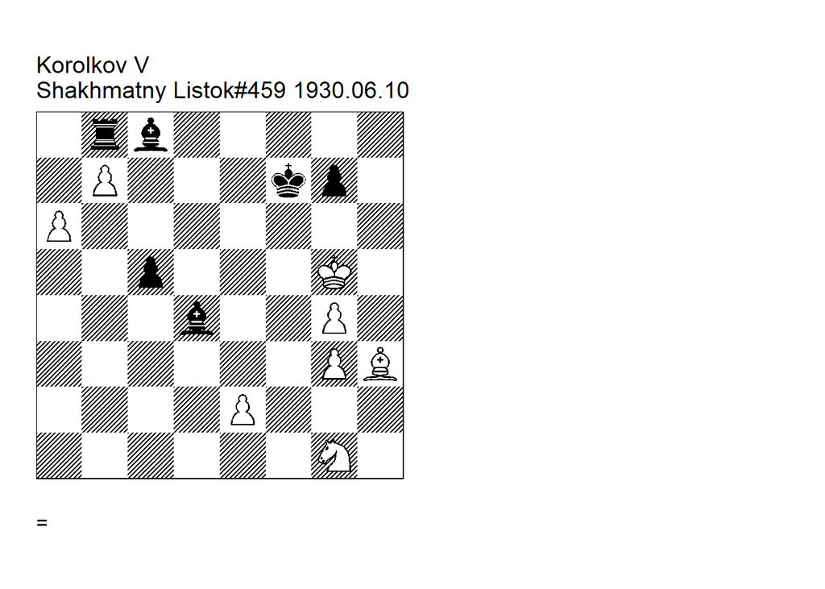

```
Korolkov V
Shakhmatny Listok#459 1930.06.10
=0371.52g5f7 cook U3
1rb5/1P3kp1/P7/2p3K1/3b2P1/6PB/4P3/6N1 w - - 0 1
Shakhmatny Listok=11. U3: Neuenschwander=B beatochess 20/05/2024. 1. a7 Be3+ 2. Kh4 Kf6!
3. Bf1! Rxb7 4. a8=Q g5+ 5. Kh3 Rh7+ 6. Kg2 Bb7+ 7. Nf3 Bxa8 ( 7... Rh2+ <cook BN> 8.
Kxh2 Bxa8 (8... Bxa8 Stockfish 16 -2.92 (depth 40)  9. Ne1 Bd5 10. Nc2 Bd2 11. Bg2 Bc4
12. Kg1 Bxe2 13. Bf1 Bxg4 14. Na3 Be1 15. Kg2 Ke5 16. Nc2 Bb4 17. Bd3 Bc3 18. Kf2 Be6 19.
Ke2 c4 20. Bg6 Ba5 21. Kf3 Bb6 22. Ke2 Bc5 23. Be8)  (8... Bxa8 -3.06 (depth 40) 9. Bg2
Bd5 10. Ne1 Bb3 11. Bc6 Ke5 12. Kg2 c4 13. Nf3+ Kd6 14. Be4 Kc5 15. Ne5 c3 16. Kf3 Bd2
17. Nd3+ Kc4 18. Ne5+ Kd4 19. Nc6+ Kc5 20. e3 c2 21. Nd4 c1=N 22. Bb7 Bd5+ 23. Bxd5)
(8... Bxa8 -4.19 (depth 40) 9. Bh3 Be4 10. Bg2 Bh7 11. Ne1 c4 12. Bc6 Bf2 13. Nf3 c3 14.
Ba4 c2 15. Bxc2 Bxc2 16. Kg2 Be3 17. Kf1 Bb3 18. Ke1 Be6 19. Nh2 Ke5 20. Nf3+ Ke4 21. Nh2
Kd5 22. Kf1 Kc4 23. Nf3)  (8... Bxa8 -4.21 (depth 40) 9. Kh3 c4 10. Bg2 Be4 11. Ne1 Bg6
12. Bc6 Bf2 13. Nf3 c3 14. Ba4 c2 15. Bxc2 Bxc2 16. Kg2 Be3 17. Kf1 Bb3 18. Ke1 Be6 19.
Nh2 Ke5 20. Nf3+ Ke4 21. Nh2 Kd5 22. Kf1 Kc4 23. Nf3) ) 1/2-1/2.
```

### Gorgiev +0144.03c1e1 (1930). Correction

Date: 2024, March 18

File: Gorgiev1930.pgn

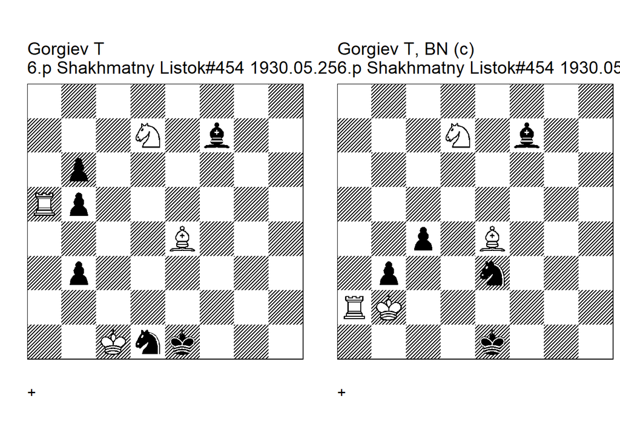

```
Gorgiev T
6.p Shakhmatny Listok#454 1930.05.25
+0144.03c1e1 cook U1
8/3N1b2/1p6/Rp6/4B3/1p6/8/2Knk3 w - - 0 1
Shakhmatny Listok=10 . U1: Van_der_Heijden=H HHdbVI 8-12-2016. 1. Ra7! (1. Ra3? b4! 2.
Ra7 b2+ 3. Kc2 Nc3)  (1. Ra8! <cook HH> 1... b2+ 2. Kc2 b1=Q+ 3. Kxb1 Nc3+ 4. Kc2! Nxe4
5. Ne5 Bh5 6. Nd3+ Kf1 7. Ra1+ Kg2 8. Nf4+ Kg3 9. Nxh5+) 1... b2+ 2. Kc2! b1=Q+ 3. Kxb1
Nc3+ 4. Kc1! Nxe4 5. Nf6! Ng5 (5... Nxf6 6. Re7+ Ne4 (6... Be6 7. Rxe6+ Kf2 8. Rxf6+)
(6... Kf2 7. Rxf7) 7. Rxe4+ Kf2 8. Rf4+) 6. Re7+ (6. Nh7? Nxh7 7. Re7+ Be6! 8. Rxe6+ Kf2
9. Rg6 Ke3!) 6... Be6! (6... Kf2 <main> 7. Nh7! Nxh7 8. Rxf7+ Kg3 9. Rxh7) 7. Ne4! Nxe4
8. Rxe6 Kf2 9. Rxe4 1-0.


Gorgiev T, BN (c)
6.p Shakhmatny Listok#454 1930.05.25
+0144.02b2e1 (c)
8/3N1b2/8/8/2p1B3/1p2n3/RK6/4k3 w - - 0 1
correction: Neuenschwander=B beatochess 18/03/2024. 1. Ra7 Nd1+ 2. Kc1 b2+ 3. Kc2 b1=Q+
4. Kxb1 Nc3+ 5. Kc1 Nxe4 6. Nf6! Ng5 (6... Nxf6 7. Re7+! Ne4 ( 7... Kf2 8. Rxf7)  (7...
Be6 8. Rxe6+ Kf2 9. Rxf6+) 8. Rxe4+ Kf2 9. Rf4+) 7. Re7+! (7. Nh7? Nxh7 8. Re7+ Be6!
(8... Kf2? 9. Rxf7+ Ke3 10. Rxh7) )  7... Be6 (7... Kf2 <main> 8. Nh7! Nxh7 9. Rxf7+ Ke3
10. Rxh7) 8. Ne4! Nxe4 9. Rxe6 Kf2 10. Rxe4 1-0.
```

### Grigoriev +0000.33e4f6 (1930). Dual

Date: 2024, March 18

File: Grigoriev1930.pgn

In Grigoriev’s study, there is the dual **6. h8=Q+** at move 6.

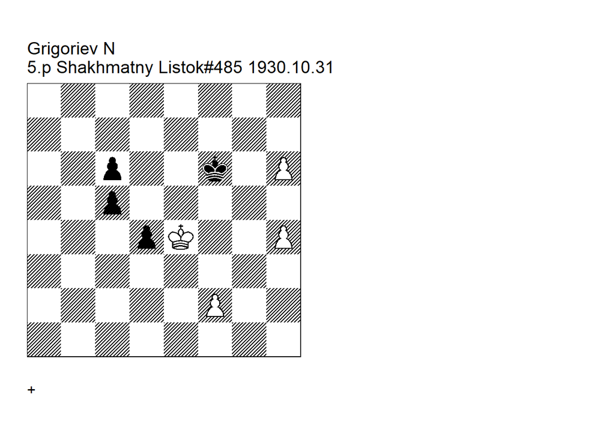

```
Grigoriev N
5.p Shakhmatny Listok#485 1930.10.31
+0000.33e4f6
8/8/2p2k1P/2p5/3pK2P/8/5P2/8 w - - 0 1
Shakhmatny Listok=20 . 1. h5! Kf7 2. f4! Kg8! 3. f5! (3. Kd3? Kh8! 4. f5 Kh7 5. f6 Kxh6
6. Ke4 Kh7) 3... Kf7 (3... Kh7 4. f6! Kxh6 5. Kd3)  ( 3... Kh8 4. f6) 4. Kd3! (4. h7? Kg7
5. f6+ Kxh7 6. Kf5 d3 7. f7 d2! 8. f8=Q d1=Q 9. Qf7+ Kh8 10. Qe8+ Kh7!) 4... Kf6 5. h7!
Kg7 6. f6+! (6. Ke4? Kh8!)  (6. h8=Q+! <or> 6... Kxh8 7. f6 Kh7 8. Ke4 Kh6 9. Ke5 etc.
<main line> ) 6... Kxh7 7. Ke4! Kh6 (7... Kg8 8. h6) 8. Kf5 (8. Ke5 <or> ) 8... d3! 9. f7
Kg7 10. Ke6 d2 11. h6+ Kg6 (11... Kf8 12. h7) 12. f8=Q d1=Q 13. Qg7+! (13. Qf6+? Kh5 14.
h7 Qd5+! 15. Ke7 Qe4+) 13... Kh5 14. h7! Qb3+ (14... Qe2+ 15. Qe5+)  (14... Qd5+ 15. Ke7
Qe4+ 16. Kf8) 15. Kd6! Qb8+ ( 15... Qd5+ 16. Kc7) 16. Kxc6! (16. Qc7? Qh8 17. Ke6 Kg6 18.
Qg3+ Kh6!)  ( 16. Kxc5? Qb5+ 17. Kd6 Qb4+ 18. Kc7 Qa5+ 19. Kb8 Qb5+) 16... Qc8+ (16...
Qe8+ 17. Kc7!) 17. Kb6! Qb8+ (17... Qe6+ 18. Kc7!)  (17... Qd8+ 18. Kb7! Qd5+ 19. Kc7!)
18. Kxc5 (18. Qb7? Qh8) 18... Qc8+ 19. Kb4! (19. Kd4? Qd8+ 20. Kc4 Qc8+) 19... Qb8+ 20.
Kc3! Qc8+ 21. Kd2! Qd8+ 22. Ke2! Qe8+ 23. Kf2! 1-0.
```

### Herbstman +4030.34a7h3 (1930). Cook?

Date: 2024, March 18

File: Herbstman1930.pgn

The study by Herbstman seems incorrect. After **3… Kg2! 4. h8=Q Qf2**, the advantage for White appears unconvincing.

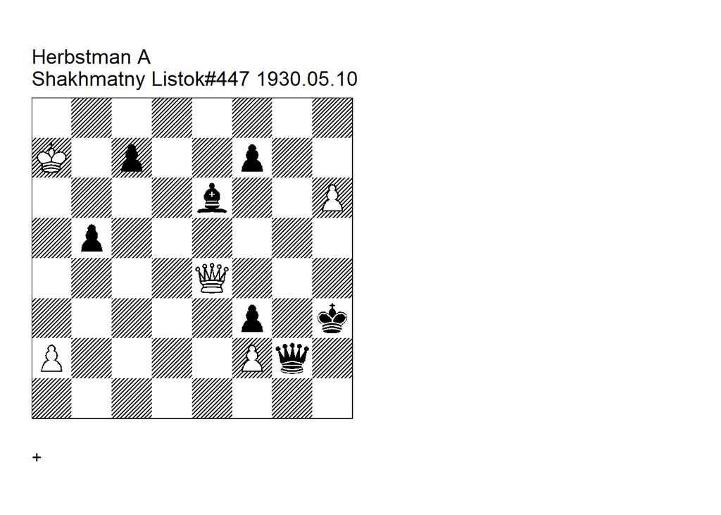

```
Herbstman A
Shakhmatny Listok#447 1930.05.10
+4030.34a7h3 cook U3
8/K1p2p2/4b2P/1p6/4Q3/5p1k/P4Pq1/8 w - - 0 1
Shakhmatny Listok=9. U3: Neuenschwander=B beatochess 18/03/2024 . 1. h7 Qxf2+ 2. Ka8
Qxa2+ 3. Kb8 Qb2 (3... Qa1 4. Qxf3+ Kh4 5. Qh1+! Qxh1 6. h8=Q+)  (3... Kg2! <cook BN> 4.
h8=Q Qf2 (4... Qf2 Stockfish 16 1.36 (depth 35) 5. Qg8+ Qg3 6. Qh8 Qf2 7. Qg7+ Qg3 8. Qh6
Bh3 9. Qf6 Be6 10. Ka8 b4 11. Qh6 b3 12. Qd4 Bh3 13. Qc1 Kh2 14. Qcc5 f5 15. Kb8 Kh1 16.
Qc1+ Kh2 17. Qcb2+ Bg2 18. Kc8 Qe1 19. Qc5)  (4... Qf2 1.30 (depth 35) 5. Qg7+ Qg3 6. Qh6
Bh3 7. Qf6 Be6 8. Ka8 Qg8+ 9. Kb7 Qg3 10. Qh6 Bh3 11. Qhc6 Qf2 12. Qxc7 f5 13. Qee5 Kg1
14. Qc1+ Qf1 15. Qcf4 Qf2 16. Qd5 Bg2 17. Qdxf5 Qe2 18. Qb1+ Bf1 19. Kc7)  (4... Qf2 1.24
(depth 35) 5. Ka8 Qa2+ 6. Kb8 Qf2 7. Qg7+ Qg3 8. Qh6 Bh3 9. Qf6 Be6 10. Ka8 Qg8+ 11. Kb7
Qg3 12. Qh6 Bh3 13. Qhc6 Qf2 14. Qxc7 Kg1 15. Qxf7 Bg2 16. Qfg6 b4 17. Qxb4 Qf1 18. Qbe4
Qb5+ 19. Kc7)  (4... Qf2 0.16 (depth 34) 5. Qa1 b4 6. Qg7+ Qg3 7. Qh6 Bh3 8. Qf6 b3 9.
Kb7 Qf2 10. Qg7+ Qg3 11. Qxf7 b2 12. Qb1 c5 13. Kc6 Qh4 14. Qxb2+ f2 15. Qd5+ Kg1 16.
Qde5 Bg2+ 17. Kxc5 f1=Q 18. Qbd4+ Qxd4+ 19. Qxd4+) ) 4. Qxf3+ Kh4! 5. Qf4+! Kh5 6. Qh2+!
Qxh2 7. h8=Q+ 1-0.
```

### Lapin/Garcia +0113.13c3e2 (1930). Cook?

Date: 2024, March 16

File: Lapin1930.pgn

The correction by Garcia is not convincing. It seems that **2. Bc4+ Kg1 3. Rh5!** (instead of 3.Rxh7) leads to an alternative win, although the lines are a bit murky.

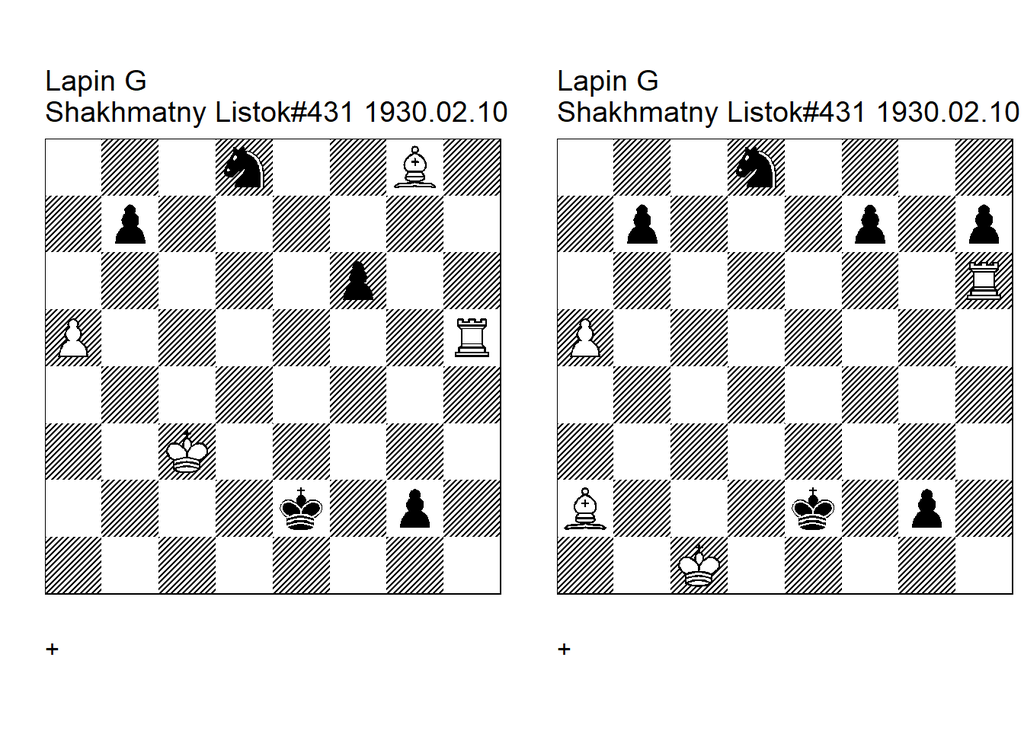

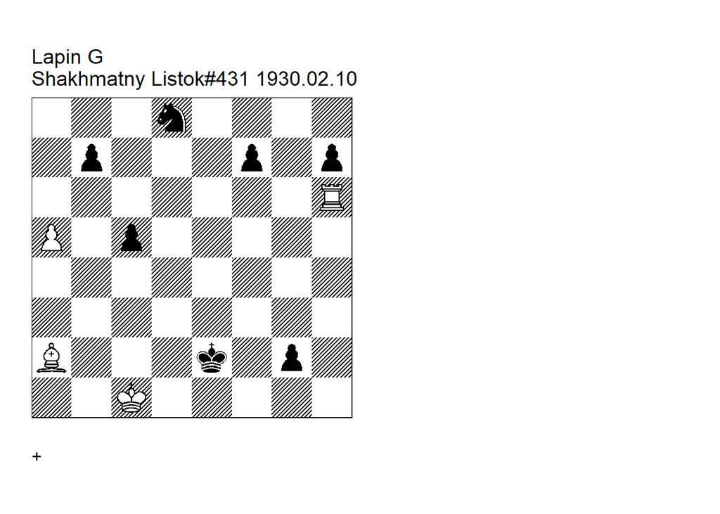

```
Lapin G
Shakhmatny Listok#431 1930.02.10
+0113.13c3e2 cook U2
3n2B1/1p6/5p2/P6R/8/2K5/4k1p1/8 w - - 0 1
Shakhmatny Listok=3 . U2: Shakhmatny Listok=15-16 10-8-1930 (U2): Haworth=G Bleicher=E
HHdbV#71040 9-12-2009. 1. Rh2 Kf1 2. Kd2 (2. Bc4+! <cook> Kg1 3. Rh6 Kf2 4. Rxf6+ Ke3 5.
Rg6 Kf2 6. Kb4 g1=Q 7. Rxg1 Kxg1 8. Bd5 Kf2 9. Bxb7 Nxb7 10. a6 Nd8 11. Kb5 Ne6 12. Kb6)
2... Kg1 3. Rh3! Kf2 4. Bd5! g1=Q 5. Rf3+ Kg2 6. Rxf6+ Kh3 7. Rh6+ Kg3 8. Rg6+ Kf2 9.
Rxg1 Kxg1 10. Bxb7 (10. Ke3! <minor_dual GH/EB>) 10... Nxb7 11. a6 1-0.


Lapin G
Shakhmatny Listok#431 1930.02.10
+0113.14c1e2 cook (c) U2
3n4/1p3p1p/7R/P7/8/8/B3k1p1/2K5 w - - 0 1
Shakhmatny Listok=3 . correction: Lapin=G 64#590 64=5 5/1932. U2: Garcia=M Estudios
Artisticos  de Ajedrez - VI-44 2012. 1. Rh2 Kf1 2. Kd2 (2. Bc4+! <cook MG> 2... Kg1 3.
Rxh7 Kf2 4. Rh2 Kg3 5. Rxg2+ Kxg2 6. Bd5+ Kf2 7. Bxb7 Ne6 8. Kc2 Ke3 9. Kc3 Nc7 10. Kc4
Kd2 11. Kc5 Kc3 12. Kb6 Kb4 13. Bc6 f5 14. Bf3) 2... Kg1! 3. Rh3! Kf2 4. Bd5 g1=Q 5. Rf3+
Kg2 6. Rxf7+ Kg3 7. Rg7+ Kf2 8. Rxg1 Kxg1 9. Ke2 h5 10. Bxb7 Ne6 (10... Nxb7 11. a6 Nd6
12. a7 Nb5 13. a8=Q) 11. a6 Nc7 12. a7 h4 13. Kd3 1-0.
```

```
Lapin G
Shakhmatny Listok#431 1930.02.10
+0113.15c1e2 cook (c) U2
3n4/1p3p1p/7R/P1p5/8/8/B3k1p1/2K5 w - - 0 1
Shakhmatny Listok=3 . correction: Garcia=M Estudios Artisticos  de Ajedrez - VI-44 2012.
U2: Neuenschwander=B beatochess 16/03/2024. 1. Rh2 Kf1 2. Kd2 (2. Bc4+? Kg1 3. Rxh7 (3.
Rh5! <cook BN> e.g. 3... Kf2 ( Stockfish 16 3.29 (depth 41) 3... Kf2 4. Rf5+ Ke3 5. Rg5
Nc6 6. Rxg2 Nxa5 7. Bxf7 h5 8. Rg3+ Kd4 9. Rh3 Nc6 10. Rh4+ Kd3 11. Bd5 Na5 12. Rh3+ Kd4
13. Bg8 Nc6 14. Rh4+ Kd3 15. Rxh5 b6 16. Rh3+ Ke4 17. Rh6 Ne5)  ( 3.29 (depth 41) 3...
Nc6 4. Bd5 Nxa5 5. Rg5 Kf2 6. Rxg2+ Ke3 7. Bxf7 h5 8. Rg3+ Kd4 9. Rh3 Nc6 10. Rh4+ Kd3
11. Bd5 Na5 12. Rh3+ Kd4 13. Bg8 Nc6 14. Rh4+ Kd3 15. Rxh5 b6 16. Rh3+ Ke4 17. Rh6 Ne5)
( 5.10 (depth 41) 3... Ne6 4. Bd5 Nf4 5. Bxb7 Nxh5 6. a6 Kf2 7. Bxg2 Kxg2 8. a7 f5 9.
a8=Q+ Kf2 10. Qa2+ Kf3 11. Qd5+ Kf4 12. Qd2+ Kg4 13. Qd1+ Kg5 14. Kd2 Nf4 15. Qg1+ Kf6
16. Qxc5 Ng6 17. Qd6+ Kf7)  ( 6.47 (depth 40) 3... f6 4. Bd5 c4 5. Rf5 Ne6 6. Bxe6 Kh2 7.
Rf2 Kg3 8. Rxg2+ Kxg2 9. Bd5+ Kg3 10. Bxb7 h5 11. a6 h4 12. Kc2 h3 13. Kc3 Kf4 14. Bh1
Ke5 15. Kxc4 Kd6 16. Kd4 Ke6 17. Kc5 Ke7) 4. Rf5+ Ke3 5. Rg5 Kf2 6. Bd5 g1=Q+ 7. Rxg1
Kxg1 8. Bxb7 Ne6 9. Kc2 h5 10. Kc3 h4 11. Kc4 h3 12. a6 h2 13. a7 Nc7 14. Kxc5) 3... Kf2
4. Rh2 Kg3 5. Rxg2+ Kxg2 6. Bd5+ Kf2 7. Bxb7 Ne6 8. Kd2 c4 9. Kc3 Nc5 10. Kxc4 Nxb7 11.
a6 Nd6+ 12. Kc5 Nc8 ) 2... Kg1! (2... c4 3. Bxc4+ Kg1 4. Rh3 Kf2 5. Bd5) 3. Rh3! Kf2 4.
Bd5 g1=Q 5. Rf3+ Kg2 6. Rxf7+ Kg3 7. Rg7+ Kf2 8. Rxg1 Kxg1 9. Ke2 (9. Kc2 <or> )  9... h5
10. Bxb7 Ne6 <eg> 11. a6 Nc7 12. a7 h4 13. Kd3 1-0.
```

### Selezniev +0301.34a4d4 (1930). Cook/correction

Date: 2024, March 15

File: Selezniev1930.pgn

Unfortunately, the promotion to a rook **4. c8=R!** gives White an overwhelming advantage, although **4. c8=B!** wins much more easily of course. The correction adds the Excelsior theme to the study.

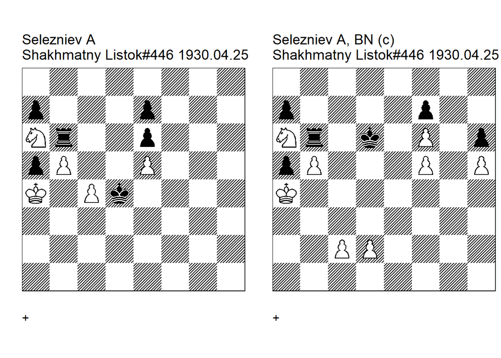

```
Selezniev A
Shakhmatny Listok#446 1930.04.25
+0301.34a4d4 cook U2
8/p3p3/Nr2p3/pP2P3/K1Pk4/8/8/8 w - - 0 1
Shakhmatny Listok=8. U2: Neuenschwander=B 2024 . 1. c5 Rxa6! 2. c6 Kc5! 3. c7 Kb6! 4.
c8=B (4. c8=Q?)  (4. c8=R! <cook BN> 4... Kb7 5. Rh8 gives White a big advantage 5... Rb6
6. Re8 (6. Re8 Stockfish 16 6.64 (depth 42) 6... Kc7 7. Rxe7+ Kb8 8. Kxa5 Rb7 9. Re8+ Kc7
10. Rxe6 Kd8 11. Ka6 Rh7 12. Rc6 Rg7 13. Rc5 Re7 14. e6 Rh7 15. Rd5+ Kc8 16. Rd7 Rh6 17.
Re7 Kd8 18. Rxa7 Rxe6+ 19. b6 Re3 20. Kb7 Rb3)  (6. Re8 33.29 (depth 41) 6... a6 7. Rxe7+
Kb8 8. bxa6 Rb1 9. Kxa5 Rc1 10. Kb6 Rb1+ 11. Kc5 Rc1+ 12. Kd6 Ra1 13. Rb7+ Kc8 14. Rb6
Ra3 15. Rc6+ Kd8 16. Kxe6 Ra5 17. Kd6 Ra2 18. Rb6 Rd2+ 19. Kc6 Rc2+ 20. Kb7 )  (6. Re8
#-23 (depth 41) 6... Rc6 7. bxc6+ Kxc6 8. Rd8 Kc7 9. Rd1 Kb7 10. Kxa5 Kc6 11. Ka6 Kc5 12.
Kxa7 Kc6 13. Kb8 Kc5 14. Kc7 Kc4 15. Kc6 Kb3 16. Rd7 Kc4 17. Rxe7 Kd3 18. Rxe6 Ke4 19.
Kd6 Kd4 20. Re7)  (6. Re8 #-15 (depth 41)  6... Rd6 7. Rxe7+ Rd7 8. Rxd7+ Kb6 9. Re7 Kc5
10. Rxa7 Kd5 11. Kxa5 Kxe5 12. Rd7 Ke4 13. b6 Ke5 14. b7 Kf4 15. b8=Q+ e5 16. Qa8 e4 17.
Re7 Ke3 18. Qxe4+ Kd2 19. Rd7+ Kc3 20. Qb1) )  (4. c8=N+? Kb7) 1-0.


Selezniev A, BN (c)
Shakhmatny Listok#446 1930.04.25
+0301.64a4d6 (c)
8/p4p2/Nr1k1P1p/pP3P1P/K7/8/2PP4/8 w - - 0 1
correction/modifcation: Neuenschwander=B beatochess 15/03/2024. 1. c4 (1. Kxa5? Kd5) 1...
Ke5 (1... Kd7 2. Nc5+! Kd6 (2... Kd8 3. Ne4 +-) 3. d4 +-) 2. d4+! (2. c5? Rxf6 3. d4+
Kd5! 4. Kxa5 Rxf5 5. c6 Kd6 =)  (2. Kxa5? Rd6 3. c5 Rxd2 4. Nb4 Rd1! 5. Ka6 Rb1! 6. c6
Kd6 7. Nd5 Rc1 8. Kb7 a6! 9. bxa6 ( 9. b6 Rxc6 =) 9... Rb1+ 10. Nb6 Kc5 11. c7 Rxb6+ 12.
Ka7 Rc6 13. Kb7 Rb6+ 14. Kc8 Rxa6 15. Kd8 Rd6+ 16. Ke7 Rc6 =) 2... Kxd4 (2... Kxf6 3. c5
Rb7 4. c6 Re7 5. Kxa5 +-) 3. c5 Rxa6 4. c6 Kc5 5. c7 Kb6 6. c8=B! 1-0.
```

### Bron +0400.52h6a5 (1929). Comment

Date: 2024, March 5

File: Bron1929.pgn

It seems that the claimed cook **1. b7** is dangerous but not sufficient for a win due to **4… Ka7!**

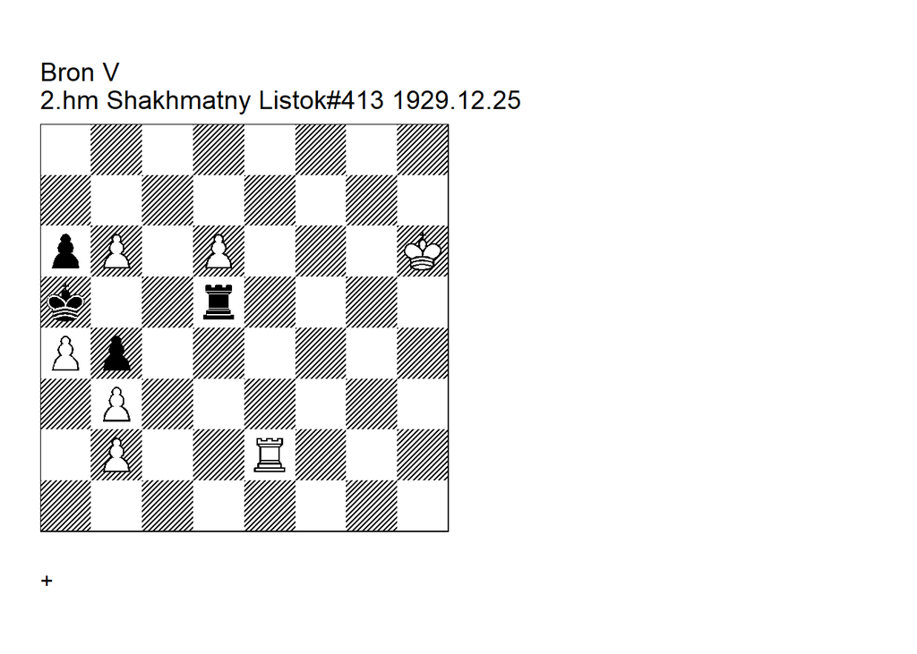

```
Bron V
2.hm Shakhmatny Listok#413 1929.12.25
+0400.52h6a5 cook U1
8/8/pP1P3K/k2r4/Pp6/1P6/1P2R3/8 w - - 0 1
Shakhmatny Listok=24 . U1: De_Zeeuw=M HHdbIV#12923 1-9-2005. Neuenschwander=B beatochess
05/032024: the claim seems incorrect according to Stockfish-16. 1. Re5! (1. b7! <cook MZ>
1... Rxd6+ 2. Kg5! Rd8 (2... Rd5+ 3. Kf6 Rd8 4. Ke7 Rb8 5. Kd6 Kb6 (5... Rxb7 6. Re5+ Kb6
7. a5+ Ka7 8. Re7) 6. Re7 Ka5 7. Kc6 Rc8+ 8. Kd5 Rb8 9. Kd6 Rxb7 10. Re5+) 3. Kf6 Rb8
(3... Kb6 4. Re7 Rb8 (4... Ka7! <BN>  (4... Ka7! <BN> Stockfish 16 0.00 (depth 54) 5. Re4
Kxb7 6. Rxb4+ Ka7 7. Ke5 Rd2 8. a5 Rxb2 9. Kd5 Rd2+ 10. Rd4 Rc2 11. Re4 Rd2+ 12. Kc5 Rd7
13. Kc4 Rc7+ 14. Kb4 Rb7+ 15. Ka3 Rb5 16. b4 Kb7 17. Re7+ Kb8 18. Rd7 Ka8 19. Ka4 Rh5)
(4... Ka7! <BN> 0.00 (depth 54) 5. a5 Rd3 6. Ke5 Rxb3 7. Kd4 Rxb2 8. Re6 Kxb7 9. Rb6+ Kc7
10. Kc4 Rb1 11. Rh6 b3 12. Kc3 Rc1+ 13. Kb2 Rc5 14. Kxb3 Rb5+ 15. Kc4 Kb7 16. Rh7+ Kb8
17. Rh8+ Ka7 18. Re8 Rb2 19. Re7+ Kb8)  (4... Ka7! <BN> 0.00 (depth 53) 5. b8=Q+ Kxb8 6.
Ke6 Rd2 7. Rd7 Rxb2 8. Kd5 Rc2 9. a5 Rc3 10. Rd6 Rxb3 11. Rxa6 Rb2 12. Rb6+ Ka7 13. Kc4
Ra2 14. Kb3 Ra3+ 15. Kxb4 Re3 16. Kc4 Re7 17. Kc3 Re2 18. Kd4 Rd2+ 19. Kc5 Rc2+) ) 5. Ke5
Rxb7 6. Rxb7+ Kxb7 7. Kd5) 4. Re5+ Kb6 5. Re7 Ka5 (5... Ka7 6. Ke6 Kb6 7. Kd5 Ka5 8. Kc6)
6. Ke5 Rxb7 (6... Rd8 7. Rc7 Rb8 8. Kd6 Rxb7 9. Rc5+ Kb6 10. a5+ Ka7 11. Rc7) 7. Kd6 Rb8
(7... Rb6+ 8. Kd5 Rc6 9. Re5 (9. Kxc6?) 9... Rc2 10. Kd6+ Kb6 11. a5+ Ka7 12. Re7+ Ka8
13. Kd5 Rxb2 14. Kc4 Rh2 15. Kxb4) 8. Re5+ Kb6 9. a5+ Ka7 (9... Kb7 10. Re7+ Ka8 11. Kc6)
10. Kc5 Rb5+ 11. Kd4)  (1. Re6? Rxd6 2. Rxd6) 1... Rxe5 2. d7 Re6+! (2... Rf5 3. d8=Q
Rf6+ 4. Kh5 Rf5+ (4... Rh6+ 5. Kg4 Rg6+ 6. Qg5+) 5. Qg5)  (2... Rd5 3. b7) 3. Kg5! Rxb6!
4. d8=N! (4. d8=Q?) 4... Rb8 (4... Rd6  <main> 5. Nb7+ Kb6 6. Nxd6) 5. Nc6+ Kb6 6. Nxb8
1-0.
```

Date: 2024, March 3

File: Havasi1929.pgn

**1. g6** is a serious dual, because after 1… Ne6, White plays 2.b4! (instead of 2.f5), which transposes into the main line.

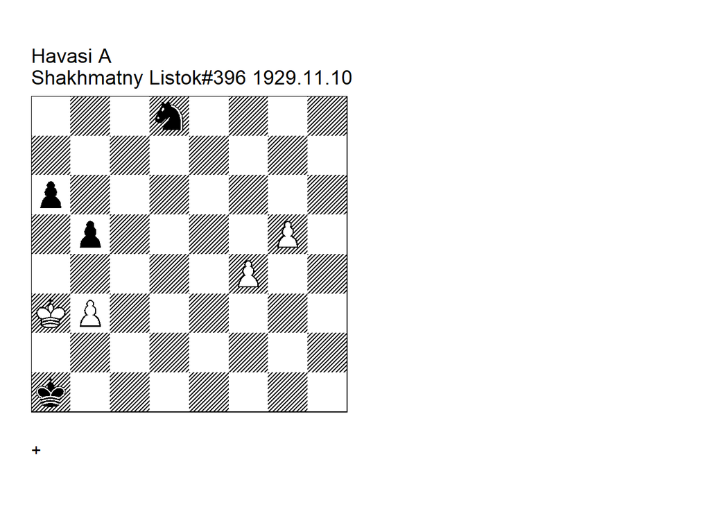

```
Havasi A
Shakhmatny Listok#396 1929.11.10
+0003.32a3a1 cook U1
3n4/8/p7/1p4P1/5P2/KP6/8/k7 w - - 0 1
Shakhmatny Listok=21. U1: Neuenschwander=B beatochess 03/03/2024 . 1. b4! ( 1. f5? a5! 2.
f6 Nc6 3. f7 Nd4 4. f8=Q Nc2#)  (1. g6? Ne6 2. f5 (2. b4! <cook BN> leads to the main
variation ) 2... Nd4)  (1. Kb4? Ne6 2. g6 Nxf4 3. g7 Nd5+ 4. Ka5 Ne7! 5. Kxa6 Kb2 6. b4
Kc3 7. Kxb5 Kd4 8. Kb6 Ke5 9. Kc7 Kf6 10. Kd7 Kf7) 1... Ne6 2. g6 Ng7 3. Kb3 Ne6 4. Kc2
1-0.
```

### Prokop =4160.22e5a2 (1929). Cook, correction

Date: 2024, March 1

File: Prokop1929.pgn

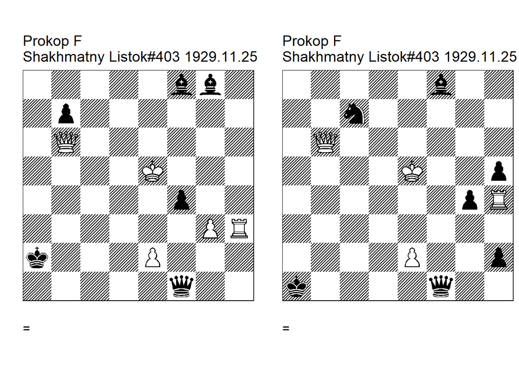

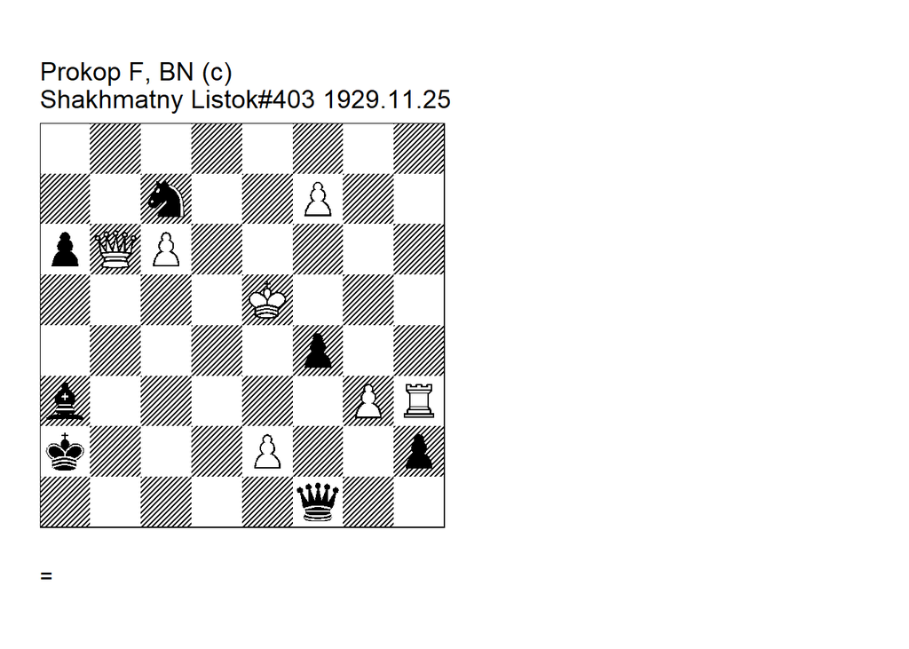

```
Prokop F
Shakhmatny Listok#403 1929.11.25
=4160.22e5a2 cook U3
5bb1/1p6/1Q6/4K3/5p2/6PR/k3P3/5q2 w - - 0 1
Shakhmatny Listok=22 . U3: Weger=Z EBUR=1 3/1996. 1. Rh2! (1. Qa5+? Ba3!)  (1. Rh4? fxg3
2. Ra4+ Ba3 3. Qe3 Bb3) 1... fxg3! (1... Bg7+ <main>  2. Ke4 fxg3 3. e3+! gxh2 (3... g2!
<cook ZW> 4. Qa5+ Kb1 5. Qb6+ Ka1) 4. Qb2+! Kxb2 (4... Bxb2) ) 2. e4+! gxh2 3. Qf2+! Qxf2
1/2-1/2.


Prokop F
Shakhmatny Listok#403 1929.11.25
=4133.13e5a1 cook (c) U1
5b2/2n5/1Q6/4K2p/6pR/8/4P2p/k4q2 w - - 0 1
Shakhmatny Listok=22 . correction: Krug=P Estudios Artisticos  de Ajedrez - XVI-6 2015.
U1: Neuenschwander=B 2024. 1. Qd4+! (1. Rxh2? Bg7+ 2. Ke4 g3 3. e3 (3. Qa5+! <cook BN>
3... Kb1 4. Qxc7 gxh2 5. Qxh2 = (tablebase )  3... Qc4+!) 1... Kb1 (1... Ka2 2. Qc4+ Kb2
(2... Ka3 3. Qc3+ Ka4 4. Qc4+ Bb4 5. Rxh2) 3. Rxh2 Qg1 4. Rxh5) 2. Qb6+! (2. Qd3+? Kb2 3.
Rxh2 Qg1! 4. Rxh5 Qc5+ 5. Kf4 Qxh5) 2... Ka2 3. Rxh2 g3 (3... Bg7+ <main> 4. Ke4 g3 5.
e3+ gxh2 6. Qb2+ (6. Qb3+ <or> )  (6. Qa5+ <or> ) 6... Kxb2 (6... Bxb2) ) 4. e4+ gxh2 5.
Qf2+ Qxf2 1/2-1/2.
```

```
Prokop F, BN (c)
Shakhmatny Listok#403 1929.11.25
=4133.43e5a2 (c)
8/2n2P2/pQP5/4K3/5p2/b5PR/k3P2p/5q2 w - - 0 1
correction: Neuenschwander=B beatochess 01/03/2024. 1. f8=Q (1. Rxh2 fxg3 -/+) 1... Bxf8
(1... Qxe2+ 2. Kf5 Qe6+ (2... Bxf8 3. Qxc7) 3. Kg5 Be7+ 4. Kxf4 Nd5+ 5. Kf3 Nxb6 6.
Rxh2+) 2. Rxh2 fxg3 (2... Bg7+ <main> 3. Ke4 fxg3 4. e3+ gxh2 5. Qb2+ (5. Qa5+ <or> )
(5. Qb3+ <or> ) ) 3. e4+ gxh2 4. Qf2+ Qxf2 1/2-1/2.
```

### Gorgiev +0170.02e5d7 (1929). Correction

Date: 2024, February 28

File: Gorgiev1929.pgn

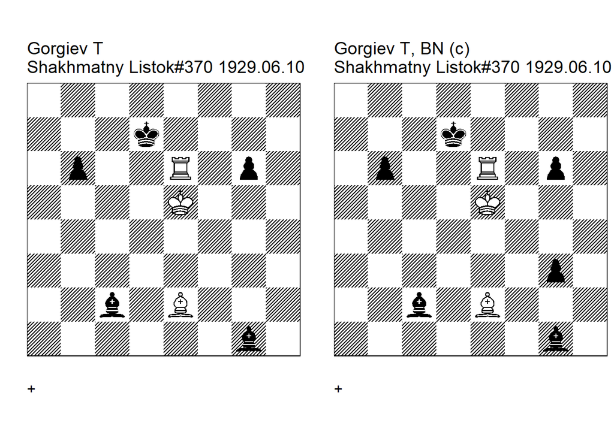

```
Gorgiev T
Shakhmatny Listok#370 1929.06.10
+0170.02e5d7 cook U2
8/3k4/1p2R1p1/4K3/8/8/2b1B3/6b1 w - - 0 1
Shakhmatny Listok=11. U2: Neuenschwander=B 2024 . 1. Bb5+ Kd8! 2. Rd6+ Ke7 3. Rd7+ Kf8!
4. Kf6 Kg8! 5. Bc4+ Kh8! 6. Rd8+! <cooks BN> White has a big advantage due to the bad
position of the black king:  (6. Rd2? Be4!)  ( Stockfish 16 5.48 (depth 35) 6. Rd8+ Kh7
7. Bg8+ Kh6 8. Bb3 Kh5 9. Bxc2 Kh4 10. Ke5 Bh2+ 11. Ke4 g5 12. Rd3 b5 13. Bd1 Bg3 14. Be2
b4 15. Kf5 Kh3 16. Bf1+ Kh2 17. Rd2+ Kg1 18. Rg2+ Kxf1 19. Rxg3 Kf2 20. Rb3)  ( 3.93
(depth 35) 6. Rd2 Be4 7. Re2 Bf3 8. Re1 Bf2 9. Rf1 Bh4+ 10. Kxg6 Be4+ 11. Kh5 Bg3 12. Kg5
Bc2 13. Kf6 Be4 14. Kf7 b5 15. Ba2 Kh7 16. Bb1 Kh6 17. Bxe4 Kg5 18. Ke6 b4 19. Bd3 Kg4
20. Bf5+)  ( 2.94 (depth 35) 6. Re7 Bf2 7. Re2 Bh4+ 8. Kf7 Bf5 9. Be6 Bb1 10. Rb2 Bd3 11.
Rb3 Bc2 12. Rb4 g5 13. Rxb6 Kh7 14. Kf8 Kg6 15. Bb3+ Kf5 16. Bxc2+ Ke5 17. Rb4 Kd5 18.
Rg4 Be1 19. Rg1 Bh4 20. Kf7)  ( 2.92 (depth 35) 6. Be6 Be3 7. Ra7 Bf2 8. Ra2 Bh4+ 9. Kf7
Bb1 10. Rb2 Bd3 11. Rb3 Bc2 12. Rb4 g5 13. Rxb6 Kh7 14. Kf8 Kg6 15. Bb3+ Kf5 16. Bxc2+
Ke5 17. Rb4 Kd5 18. Rg4 Be1 19. Kf7 Bd2 20. Re4) 6... Kh7 7. Bg8+ Kh6! 8. Bb3! (8. Be6?
g5) 8... Bd4+ ( 8... Bxb3 <main> 9. Rh8#) 9. Rxd4 Bxb3 10. Rh4# 1-0.


Gorgiev T, BN (c)
Shakhmatny Listok#370 1929.06.10
+0170.03e5d7 (c)
8/3k4/1p2R1p1/4K3/8/6p1/2b1B3/6b1 w - - 0 1
correction: Neuenschwander=B beatochess 28/02/2024. 1. Bb5+ Kd8 2. Rd6+ Ke7 3. Rd7+ Kf8
4. Kf6 Kg8 5. Bc4+ Kh8 6. Rd8+ Kh7 7. Bg8+ Kh6 8. Bb3 Bxb3 (8... Bd4+ 9. Rxd4 Bxb3 10.
Rh4#) 9. Rh8# 1-0.
```

## Tidskrift for Schack studies

### Hildebrand +0024.02f2a2 (1945). Comment

Date: 2024, June 19

File: Hildebrand1945c.pgn

Another example of a failed study due to the fact that the BB-n ending is lost.

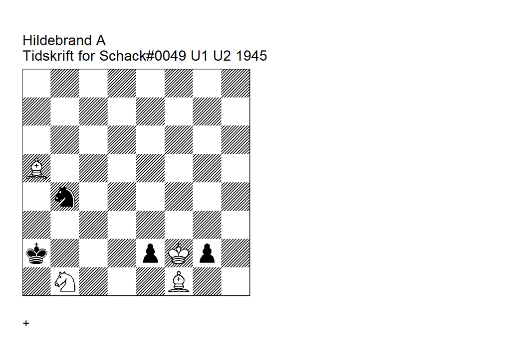

```
Hildebrand A
Tidskrift for Schack#0049 U1 U2 1945
+0024.02f2a2 cook
8/8/8/B7/1n6/8/k3pKp1/1N3B2 w - - 0 1
Tidskrift for Schack=8 Tidskrift for Schack/8. U1 U2 Neuenschwander=B beatochess
19/06/2024. 1. Bxg2! (1. Bxe2? Nc6! 2. Nc3+ Kb3)  (1. Bxe2! <cook BN> 1... Nc6 2. Bc3
Kxb1 3. Kxg2) 1... Nd3+ 2. Kxe2 Nc1+ (2... Nf4+ 3. Kf3 Nxg2 4. Nc3+ Kb3 5. Kxg2) 3. Kd2!
(3. Kd1? Kxb1 4. Be4+ Kb2)  (3. Ke3 <cook BN>any kiing move wins ) 3... Nb3+ (3... Kxb1
4. Be4+ Kb2 5. Bc3+ Kb3 6. Bd5+) 4. Kc2 Nxa5 5. Bd5+ Ka1 6. Nd2! 1-0.
```

### Hannemann =0011.02b8b3 (1945). Version

Date: 2024, June 18

File: Hannemann1945.pgn

In Hannemann’s study, **1. Ne4** is not a cook. The other cooks remain though. The version shows the sacrifice of the white bishop twice (on a4 and a6). Either black takes the bishop or the well-known BN-q theoretical draw is reached.

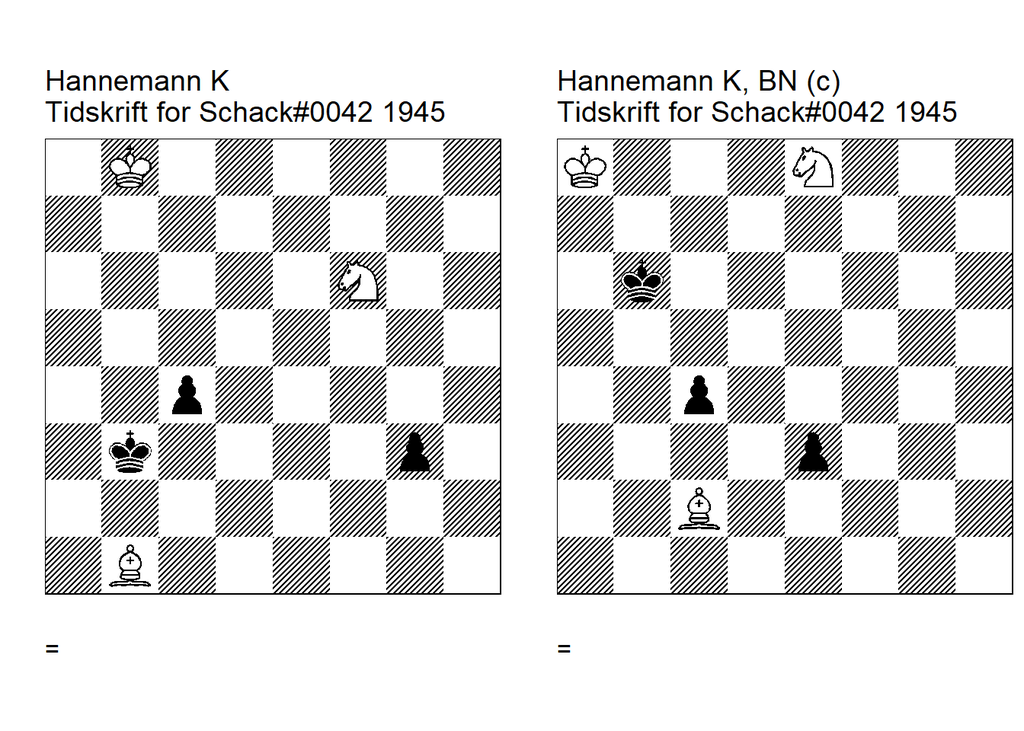

```
Hannemann K
Tidskrift for Schack#0042 1945
=0011.02b8b3 cook U1 U2
1K6/8/5N2/8/2p5/1k4p1/8/1B6 w - - 0 1
Tidskrift for Schack=7 Tidskrift for Schack/7. U1   U2: Tidskrift for Schack=10 10/1945
Comment Neuenschwander=B 18/06/2024. 1. Be4 (1. Ne4! <cook> 1... g2 2. Nd2+ Kb2 3. Nxc4+
Kc1 4. Be4 <commnt BN: black is winning!> ) 1... c3 2. Ka7 (2. Ka8! <cook> 2... Ka3 3.
Nd5 c2 4. Bxc2 g2 5. Ba4! g1=Q (5... Kxa4 6. Nc3+ Kb3 7. Ne2) 6. Bc6)  (2. Nd5!    <cook>
 2... g2 3. Bxg2 c2 4. Bf1 c1=Q 5. Ba6) 2... Ka3 (2... Kb2 3. Nd5 c2 4. Nb4)  ( 2... Ka2
3. Nd5 c2 4. Nb4+) 3. Ka8 c2 4. Bxc2 g2 5. Be4 g1=Q 6. Bb7 1/2-1/2.


Hannemann K, BN (c)
Tidskrift for Schack#0042 1945
=0011.02a8b6 (v)
K3N3/8/1k6/8/2p5/4p3/2B5/8 w - - 0 1
version: Neuenschwander=B beatochess 18/06/2024. 1. Bd1 c3 2. Nf6 Ka5 3. Nd5 c2 (3... e2
<main> 4. Bxe2 c2 5. Ba6! c1=Q 6. Kb7) 4. Bxc2 e2 5. Ba4! e1=Q 6. Bc6 1/2-1/2.
```

### Terho +0345.46h2a8 (1945). Comment

Date: 2024, June 18

File: Terho1945.pgn

Terho’s study is incorrect: **5.c5!** also wins.

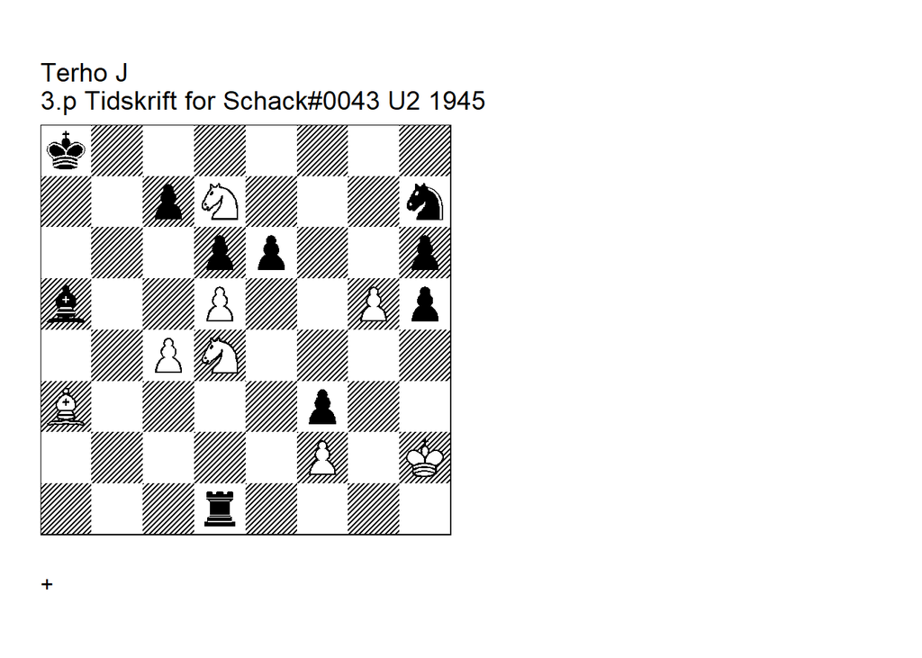

```
Terho J
3.p Tidskrift for Schack#0043 U2 1945
+0345.46h2a8 cook
k7/2pN3n/3pp2p/b2P2Pp/2PN4/B4p2/5P1K/3r4 w - - 0 1
Tidskrift for Schack=7 Tidskrift for Schack/7 U2: Neuenschwander=B beatochess 18/06/2024.
1. g6 (1. dxe6? Rxd4 2. e7 Re4) 1... Rxd4 2. gxh7 Rh4+ 3. Kg3! Rg4+ 4. Kxf3 Bc3 5. Nf6!
(5. dxe6? Rg6 6. Nf6 Rxf6+)  (5. c5! <cook BN> 5... dxc5 (5... exd5 6. cxd6 cxd6 7. Bxd6)
 (5... Rg6 6. cxd6 cxd6 7. Bxd6 exd5 8. Ne5) 6. dxe6 Rg6 7. e7 Re6 8. Bxc5) 5... Bxf6 6.
dxe6 Rg1 7. Bb4 (7. Ke2? Rg5 8. Bb2 Bxb2 9. e7) 7... Rg5 8. Bc3! Bxc3 9. e7 Re5 10. h8=Q+
1-0.
```

### Hildebrand =0034.21a5a3 (1945). Cook

The study is incorrect: black wins.

Date: 2024, June 18

File: Hildebrand1945b.pgn

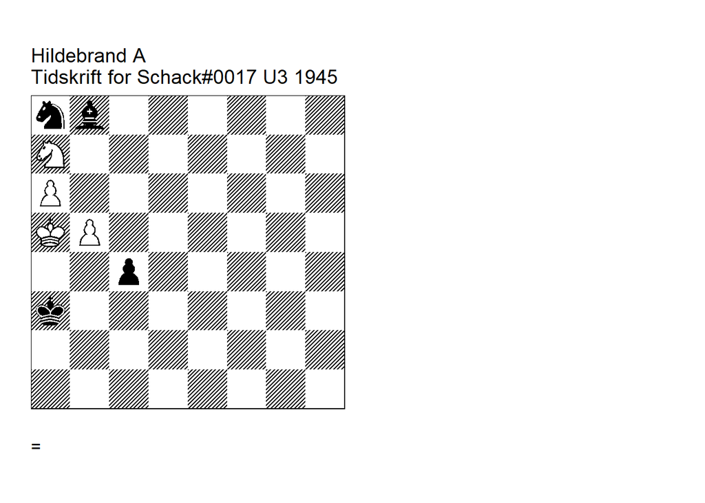

```
Hildebrand A
Tidskrift for Schack#0017 U3 1945
=0034.21a5a3 cook
nb6/N7/P7/KP6/2p5/k7/8/8 w - - 0 1
Tidskrift for Schack=3 Tidskrift for Schack/3 U3: Neuenschwander=B beatochess 18/06/2024.
1. b6! (1. Nc6? c3 2. Nb4 Bc7+ 3. b6 Bxb6+ 4. Kb5 Nc7+! 5. Kc4 (5. Kxb6 Kxb4 6. Kxc7 c2
7. a7 c1=Q+) 5... Nxa6! 6. Nd3 c2 7. Kc3 Nb4)  1... Bxa7 2. b7 Nc7 (2... Nb6 3. b8=Q Bxb8
4. Kxb6 c3 (4... Bh2 5. a7 Bg1+ 6. Kb5 Bxa7 7. Kxc4)  (4... Kb4! <cook BN> 5. Kb7 Kb5) 5.
Kb7) 3. b8=Q Bxb8 4. a7 Bxa7 1/2-1/2.
```

Date: 2024, June 7

File: Hildebrand1945a.pgn

In the correction Black wins after **4… Bc8!** due to the f-pawn. The study can be corrected by moving the f-pawn to h7.

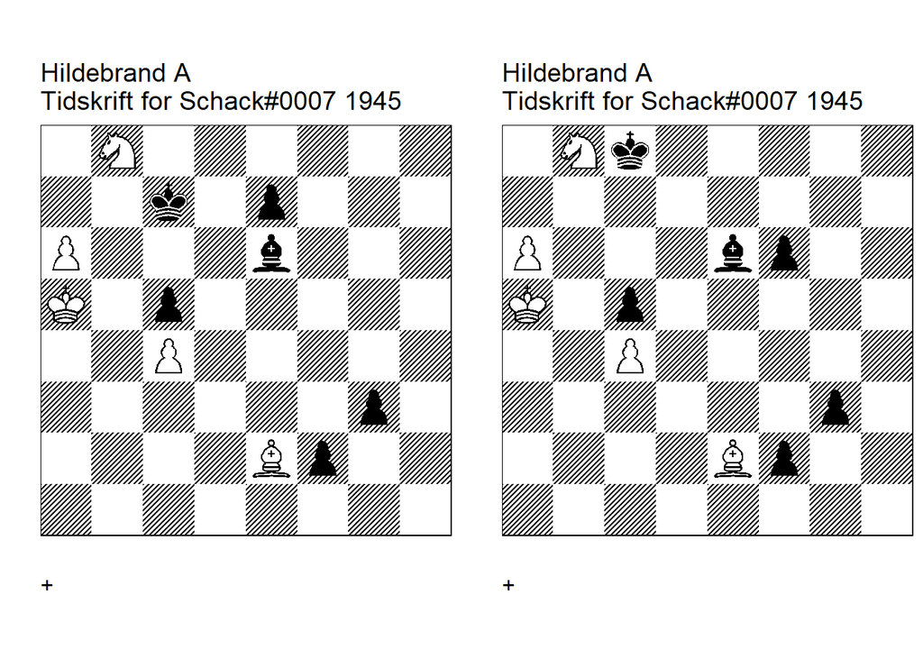

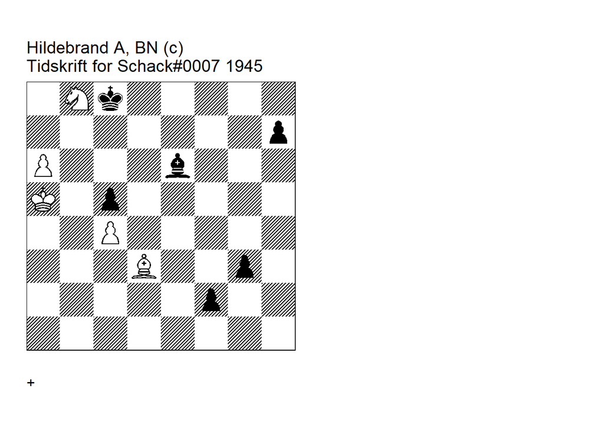

```
Hildebrand A
Tidskrift for Schack#0007 1945
+0041.24a5c7 cook U3
1N6/2k1p3/P3b3/K1p5/2P5/6p1/4Bp2/8 w - - 0 1
Tidskrift for Schack=2 Tidskrift for Schack/2. U3: Tidskrift for Schack=5 5/1945. 1. a7
Kb7 2. Bf1 Kxa7 3. Nc6+ Ka8 4. Bg2 (4. Nxe7? Kb8! 5. Nd5! Bg4 6. Ne3 Bf3 7. Kb6 Kc8 8.
Kxc5 Kc7 9. Ng2 Kb7 10. Nh4 Bc6 11. Kd4 Kb6 12. Ke3 Kc5 13. Kf4 g2) 4... f1=Q 5. Bxf1
Bxc4 6. Bg2 e6! <cook> 7. Ne5+ Bd5 1-0.


Hildebrand A
Tidskrift for Schack#0007 1945
+0041.24a5c8 cook (c) U3
1Nk5/8/P3bp2/K1p5/2P5/6p1/4Bp2/8 w - - 0 1
Tidskrift for Schack=2 Tidskrift for Schack/2. correction: Hildebrand=A Tidskrift for
Schack=6 6/1945. U3: Neuenschwander=B beatochess 07/06/2024. 1. a7 Kb7 2. Bf1 Kxa7 3.
Nc6+ Ka8 4. Bg2 f1=Q (4... Bc8! <cook BN> 5. Kb6 Bb7 6. Kxc5 f5! 7. Kd4 f4) 5. Bxf1 Bxc4
6. Bg2 1-0.
```

```
Hildebrand A, BN (c)
Tidskrift for Schack#0007 1945
+0041.24a5c7 (c)
1Nk5/7p/P3b3/K1p5/2P5/3B2p1/5p2/8 w - - 0 1
correction: Neuenschwander=B beatochess 07/06/2024. 1. a7 (1. Kb6? g2 2. a7 f1=Q 3. a8=Q
Qf6!) 1... Kb7 2. Bf1 Kxa7 3. Nc6+ Ka8 4. Bg2 f1=Q 5. Bxf1 Bxc4 6. Bg2 1-0.
```

## Miscellaneous

### Aizenshtat +0040.13c6a5 (1931). Correction

Date: 2024, June 4

File: Aizenshtat1931b.pgn

The dual in the original study is rather minor since the winning idea remains the same. The correction rectifies this minor flaw.

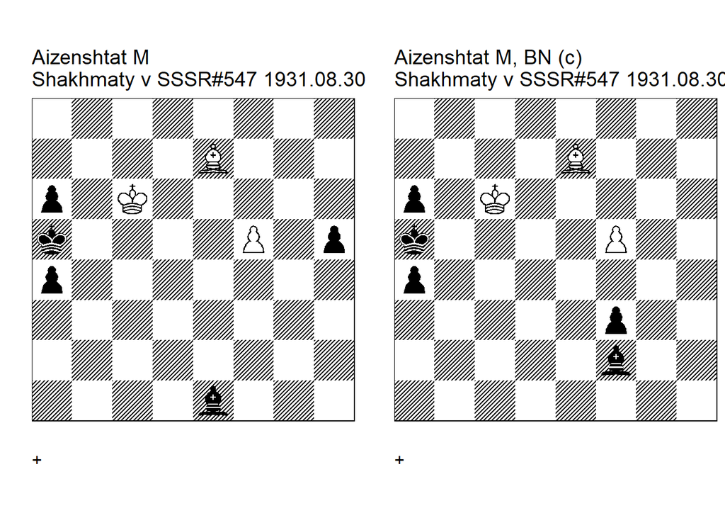

```
Aizenshtat M
Shakhmaty v SSSR#547 1931.08.30
+0040.13c6a5 U2
8/4B3/p1K5/k4P1p/p7/8/8/4b3 w - - 0 1
Shakhmaty v SSSR=16 U2: Neuenschwander=B beatochess 04/06/2024. 1. f6 Bc3 ( 1... Bd2
<main> 2. f7 Bh6 3. Bg5! Bf8 4. Bd2+)  (1... Bh4 <main> 2. Bd8+! Kb4 3. f7)  (1... a3 2.
f7 a2 3. f8=Q a1=Q 4. Qf5+ Ka4 5. Qc2+ Ka5 6. Qc5+ Ka4 7. Qc4+ Ka5 8. Bd8#) 2. f7 Bg7 3.
Bf6! (3. Ba3 <dual BN> 3... h4 4. Bb2 Bf8 5. Bc3+) 3... Bf8 4. Bc3+ Bb4 <eg> 5. f8=Q Bxc3
6. Qc5# 1-0.


Aizenshtat M, BN (c)
Shakhmaty v SSSR#547 1931.08.30
+0040.13c6a5 (c)
8/4B3/p1K5/k4P2/p7/5p2/5b2/8 w - - 0 1
correction: Neuenschwander=B beatochess 04/06/2024. 1. f6 Bd4 (1... Be3 <main> 2. f7 Bh6
3. Bg5! Bf8 4. Bd2+)  (1... Bh4 2. Bd8+ Kb4 3. f7) 2. f7 Bg7 3. Bf6! Bf8 4. Bc3+ 1-0.
```

Date: 2024, June 4

File: Aizenshtat1931a.pgn

A slower win beginning with **2. Kh6** is possible in Aizenshtat’s study.

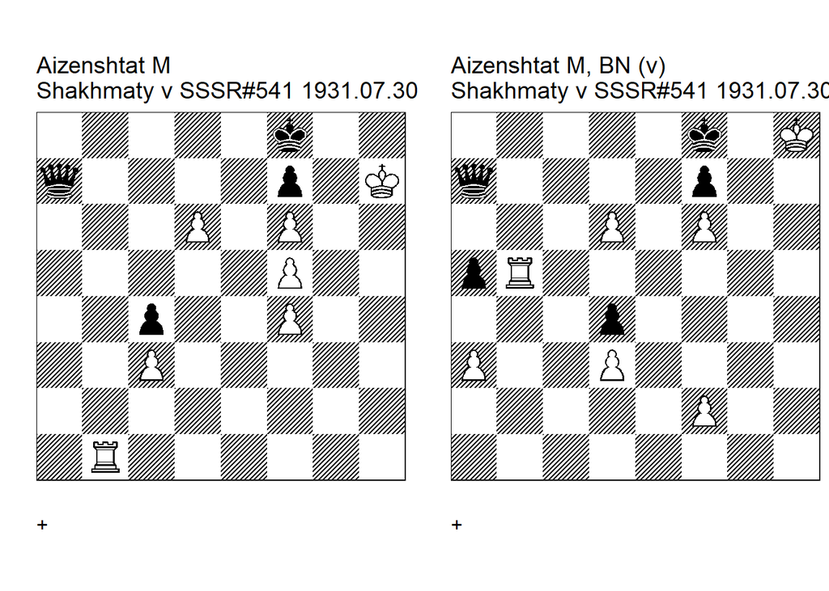

```
Aizenshtat M
Shakhmaty v SSSR#541 1931.07.30
+3100.52h7f8 cook
5k2/q4p1K/3P1P2/5P2/2p2P2/2P5/8/1R6 w - - 0 1
Shakhmaty v SSSR=14 U2: Neuenschwander=B beatochess 03/06/2024 . 1. d7 Qa8! (1... Qb6 2.
Rd1 Qd8 (2... Qd6 3. d8=Q+) 3. Rd2)  (1... Qxd7 2. Rb8+ Qe8 3. Rxe8+ Kxe8 4. Kg7) 2. Rb7!
(2. Rd1? Qh1+! 3. Rxh1)  (2. Kh6! <cook BN> 2... Qd8 3. Kh5 Kg8 4. Rd1 Kh7 5. Kg4 Qa8 6.
Rd2) 2... Qd8 3. Rb2! (3. Ra7? Qa5! 4. Kh6 Qd5! 5. Ra1 Kg8 6. Rg1+ (6. Rb1 Qd6!) 6... Kh8
7. Ra1 Kg8) 3... Qa8 4. Rg2! 1-0.


Aizenshtat M, BN (v)
Shakhmaty v SSSR#541 1931.07.30
+3100.53h8f8 (v)
5k1K/q4p2/3P1P2/pR6/3p4/P2P4/5P2/8 w - - 0 1
version: Neuenschwander=B beatochess 04/06/2024. 1. d7 Qc7 2. f4 Qd8 3. Kh7 Qa8 4. Rb1!
(4. Rb7? a4! 5. Kh8 Qd8 6. Kh7 Qa8 7. Rb1 Qh1+ 8. Rxh1) 4... a4 5. Rb7! Qd8 6. Rb2! (6.
Ra7? Qa5!) 6... Qa8 7. Rg2! 1-0.
```

### Holm +0311.24e7a4 (1912). Correction

Date: 2024, May 30

File: Holm1912.pgn

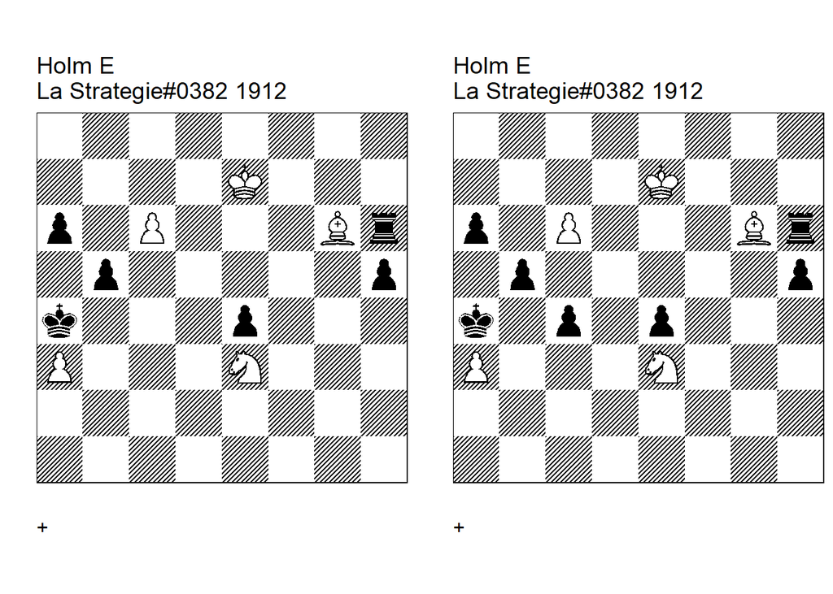

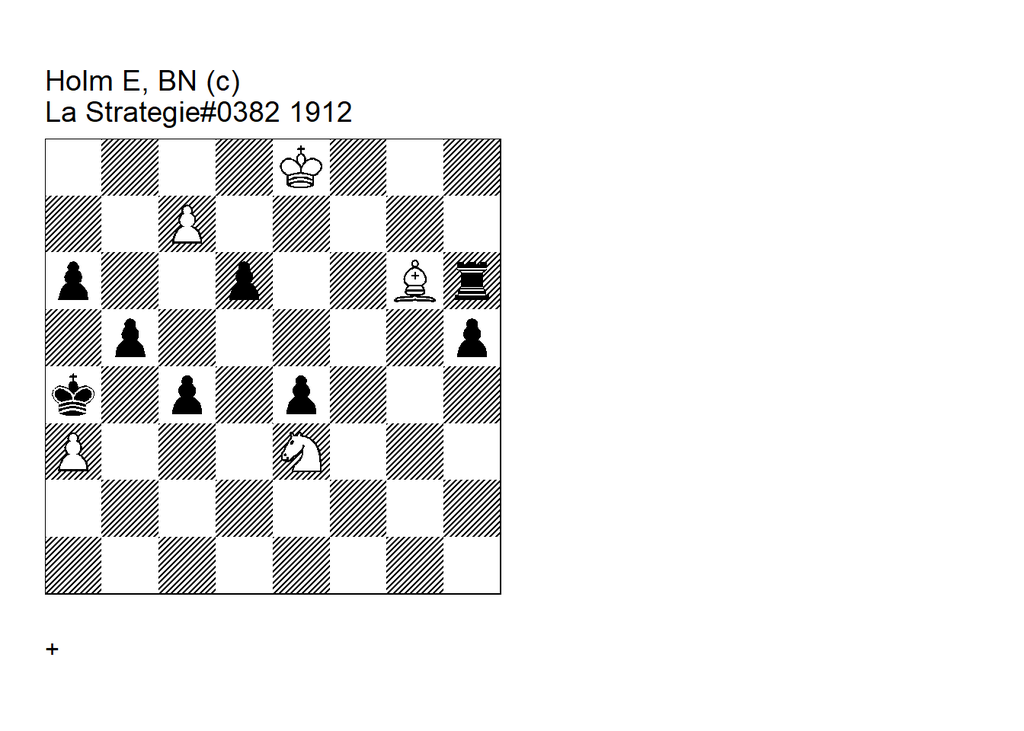

```
Holm E
La Strategie#0382 1912
+0311.24e7a4 cook U1
8/4K3/p1P3Br/1p5p/k3p3/P3N3/8/8 w - - 0 1
La Strategie/11. U1: Puig_y_Puig=E La Strategie/11 1913. 1. c7 (1. Bxe4! <cook EP> 1...
Kxa3 (1... Ka5 2. c7 Rh8 3. Bf5 b4 4. Nc4+ Kb5 5. Bd7+ Kxc4 ( 5... Kc5 6. Be8 Rh7+ 7. Bf7
Rh8 8. axb4+ Kxb4 9. Nd6) 6. Be8 Rh7+ 7. Bf7+)  ( 1... a5 2. c7 Rh8 3. Nf5 Rh7+ (3... b4
4. Bc6+ Kxa3 5. Be8 Rh7+ 6. Ng7 Rxg7+ 7. Bf7) 4. Kd6 Rxc7 5. Kxc7 b4 6. axb4 Kxb4 (6...
axb4 7. Kb6 b3 8. Nh4 Ka3 9. Nf3 h4 10. Nd2 b2 11. Kc5 Ka2 12. Kc4 h3 13. Kc3 h2 14. Kc2)
7. Bf3 a4 (7... h4 8. Nxh4 a4 9. Bd5 a3 10. Nf5 Kc3 11. Nd6 Kb2 12. Nc4+) 8. Bxh5 a3 9.
Bf7 Kc3 10. Nd6 Kb2 11. Nc4+ Kb3 12. Nb6+ Kb2 13. Na4+)  (1... b4 2. c7 Rh8 3. Bc6+ Kxa3
4. Nc4+ Ka2 5. Be8 Rh7+ 6. Bf7 Rh8 7. Nd6+)  (1... h4 2. c7 Rh8 3. Nf5 Rh7+ 4. Kd6 Rh8
(4... Rxc7 5. Kxc7 h3 6. Kb6 Kxa3 7. Nd4 b4 8. Bd5 h2 9. Nc2+ Ka4 10. Kxa6 h1=Q 11. Bxh1
Kb3 12. Be4 Kc3 13. Ka5 b3 14. Na3) 5. Kd7 h3 6. Nd6 h2 7. Ke6 Kxa3 8. Kf6 b4 9. Kg7 b3
10. Kxh8 b2 11. c8=Q h1=Q+ 12. Bxh1 b1=Q 13. Qc3+ Qb3 14. Nc4+ Ka4 15. Qa5#)  (1... Rxc6
2. Bxc6 Kxa3 (2... h4 3. Kd6 h3 4. Kc5 h2 5. Nf1 Kxa3 6. Nxh2 b4 7. Nf1 b3 8. Nd2 b2 9.
Be4) 3. Kd6 b4 (3... Kb4 4. Kd5 a5 5. Kd4 a4 6. Bd5 Ka3 7. Kc5) 4. Kc5 b3 (4... Kb3 5.
Be8 h4 6. Bf7+ Ka3 7. Nc2+ Kb2 8. Nxb4 a5 9. Nc6 a4 10. Na5 a3 11. Nc4+ Kb3 12. Nb6+ Kb2
13. Na4+) 5. Nc4+ Ka2 6. Be4 b2 (6... a5 7. Nd2 a4 8. Kb4 h4 (8... a3 9. Bd5 Kb2 10.
Nc4+) 9. Kxa4 b2 10. Bb1+ Ka1 11. Kb3 h3 12. Kc2 h2 13. Nb3#) 7. Nd2 h4 8. Kc4 h3 9. Kc3
h2 10. Kc2 a5 11. Nb1) 2. c7 Rh8 3. Nf5 Rc8 (3... Rh7+ 4. Kd6 Rh8 5. Kd7 Rh7+ 6. Ne7 Rh8
7. Bd5 Rf8 8. Nc6)  (3... Rg8 4. Bd5 Rc8 5. Kd7 Rxc7+ 6. Kxc7 b4 7. Nd4!) 4. Kd7 Rxc7+
(4... Rh8 5. Nd6 Rf8 6. Ke7 Rg8 7. Ne8)  (4... Rf8 5. Nd6 h4 6. Ke7 Rg8 7. Ne8)  (4...
Rg8 5. Bd5 Rf8 (5... Rh8 6. Nd6 Rh7+ 7. Nf7) 6. Nd6 Rh8 7. Be4 Rf8 8. Ke7 Rg8 9. Ne8) 5.
Kxc7 Kb4 (5... b4 6. Kb6 b3 7. Ka5 b2 (7... h4 8. Nxh4 b2 9. Nf3 Ka2 10. Nd2)  (7... Ka2
8. Bd5 Ka3 9. Nd4 b2 10. Nc2#)  (7... Kb2 8. Ka4 Kc3 9. Ka3 a5 10. Bc6 b2 11. Ka2 Kc2 12.
Be4+ Kc1 13. Nh4 a4 14. Nf3 a3 15. Nh4) 8. Bb1 Kb3 9. Ne3 Kc3 (9... Ka3 10. Kxa6) 10. Nf1
h4 11. Ka4)  (5... h4 6. Nxh4 Kb4 (6... b4 7. Kb6 b3 8. Nf3)  (6... a5 7. Kb6) 7. Kb6 a5
8. Bd5 a4 9. Nf5 a3 10. Nd6 Kc3 11. Kxb5 Kb2 12. Nc4+ Kb3 13. Nb6+ Kb2 14. Na4+) ) 1...
Rh8 2. Nc4 (2. Bxh5? Kxa3 3. Kd7 b4 4. c8=Q Rxc8 5. Kxc8 a5 6. Bg6 b3 7. Bxe4 a4)  (2.
Be8? Rh7+ 3. Kd8 Rxc7 4. Kxc7 h4 5. Kb6 Kxa3 6. Kxa6 b4 7. Bg6 b3 8. Bxe4 Ka2)  (2. Bxe4?
Kxa3 3. Bb7 a5 4. c8=Q Rxc8 5. Bxc8 a4 6. Kd6 b4 7. Kc5 b3 8. Bf5 b2) 2... h4 (2... a5 3.
Bxh5)  (2... bxc4 3. Be8+ )  (2... Kb3 3. Be8)  (2... Ra8 3. Nb6+) 3. Bh5 (3. Nd6? h3 4.
Nc4 bxc4 5. Be8+ Rxe8+ 6. Kxe8 h2) 3... Kb3 (3... Rxh5 4. Nb6+ (4. c8=Q bxc4 5. Qxc4+
Kxa3 6. Qxa6+ Kb4 7. Qb7+ Ka5 8. Qxe4) 4... Ka5 5. c8=Q Kxb6 6. Qe6+) 4. Be8 Rh7+ ( 4...
h3 5. c8=Q (5. Ne3? h2 6. c8=Q Rxe8+ 7. Kxe8 h1=Q 8. Qc2+ Kxa3)  (5. Nd2+? Kb2 6. Nxe4
(6. c8=Q h2 7. Qe6 h1=Q 8. Qb3+ Kc1) 6... h2 7. c8=Q Rxe8+! 8. Kxe8 h1=Q 9. Qc3+ Ka2)
5... h2 6. Qxa6 Rxe8+ 7. Kxe8 h1=Q 8. Qxb5+ Kc3 9. Qb4+ Kd3 10. Nd6! (10. Ne5+? Ke2)
10... Qh8+ 11. Kd7 Qg7+ 12. Ke6 Qg8+ 13. Ke5 Qh8+ 14. Kd5 Qa8+ 15. Kc5 Qa7+ 16. Kc6 Qa8+
17. Kd7 Qa7+ 18. Ke6 e3 19. Qb3+ Ke2 20. Nc4! Qa6+ 21. Ke5) 5. Bf7 Rh8 6. Nd6+ Kb2 (6...
```

[output cut: 17 more lines]

```
HHdbIII#61846 1-6-2004.   1. c7 Rh8 2. Nxc4! (2. Be8 Rh7+ 3. Kd8 (3. Bf7! <cook NH> 3...
Rh8 4. Nxc4 h4 5. Bh5! Kb3 6. Be8! Rh7+ 7. Bf7! Rh8 8. Nd6+ Kb2 (8... Kxa3 9. Ne8) 9.
Bg8! Rxg8 10. Ne8 e3 11. c8=Q e2 12. Qe6 Rg2 13. Qf6+ Kxa3 14. Qxa6+ Kb4 15. Qa1 h3 16.
Nd6) 3... Rxc7 4. Kxc7 Kxa3) 2... h4! (2... bxc4 3. Be8+ Kb3 4. c8=Q h4 5. Qh3+ c3 6.
Bf7+) 3. Bh5! Kb3 (3... Rxh5 4. c8=Q bxc4 5. Qxc4+ Kxa3 6. Qxa6+ Kb3 7. Qb7+ Kc3 8. Qxe4
h3 9. Qf3+) 4. Be8 Rh7+ 5. Bf7 Rh8 6. Nd6+ Kb2 7. Bg8! Rxg8 (7... h3 8. c8=Q h2 9. Nxe4
h1=Q 10. Qc3+ Kb1 11. Nd2#) 8. Ne8 e3 9. c8=Q Rg2 10. Qe6 (10. Qh3! <cook NH>  10... Re2
(10... e2 11. Qxg2)  (10... Rg3 11. Qxh4) 11. Qxh4) 10... e2 11. Nf6 (11. Qf6+! <cook NH>
11... Kxa3 12. Qxa6+ Kb4 13. Qa1 h3 14. Nd6 h2 15. Qb2+ Kc5 16. Qxb5+ Kd4 17. Qb4+ Kd3
18. Qb3+ Kd4 19. Nf5+ Ke4 20. Qe6+ Kd3 21. Qe3+ Kc2 22. Nd4+ Kd1 23. Nf3 Kc2 24. Ne1+ Kd1
25. Nd3 Kc2 26. Qe4! Kd2 27. Qxg2 Kxd3 28. Qd5+ Ke3 29. Qh1) 11... h3 12. Nd5 h2 13. Qe5+
Kc1 (13... Ka2 14. Nb4+ Kb3! 15. Qe3+ Kc4 (15... Ka4 16. Qe4) 16. Qd3+ Kc5 17. Qc3+ Kb6
18. Kd7! Rg7+ 19. Qxg7 e1=Q 20. Qf6+ Ka7 21. Qxa6+ Kb8 22. Nc6#)  (13... Kb3 14. Qc3+ Ka2
15. Nb4+ Kb1 16. Qc2+ Ka1 17. Qa2#)  (13... Kb1 14. Qe4+ Ka2 15. Qxg2) 14. Qc3+ Kb1 15.
Nb4 e1=Q+ 16. Qxe1+ Kb2 17. Qe5+ Kxa3 18. Nd5 1-0.
```

```
Holm E, BN (c)
La Strategie#0382 1912
+0311.26e8a4 (c)
4K3/2P5/p2p2Br/1p5p/k1p1p3/P3N3/8/8 w - - 0 1
correction: Neuenschwander=B beatochess 30/05/2024. 1. Ke7! Rh8 2. Nxc4! (2. Be8? Rh7+ 3.
Bf7 Rh8 4. Nxc4 d5! 5. Nb6+ Kxa3 6. Bxh5 Rh7+ 7. Bf7 Rh8)  2... h4! (2... d5 3. Nb6+ Kxa3
4. Kf7 h4 5. Kg7)  (2... bxc4 3. Be8+) 3. Bh5! Kb3 4. Be8 Rh7+ (4... h3 5. c8=Q h2 6.
Qxa6 h1=Q 7. Qxb5+ Kc2 8. Qb2+ Kd3 9. Bb5 Qh7+ 10. Kxd6 Rd8+ 11. Kc5 Qe7+ 12. Nd6+ Ke3
13. Qe2+ Kf4 14. Qf2+ Kg5 15. Qe3+ Kh5 16. Be2+ Kg6 17. Qxe4+) 5. Bf7 Rh8 6. Nxd6+ Kb2 7.
Bg8! Rxg8 (7... h3 8. c8=Q h2 9. Nxe4 h1=Q 10. Qc3+ Kb1 11. Nd2#) 8. Ne8 e3 9. c8=Q e2
10. Qe6 Rg2 <eg> 11. Nf6 h3 12. Qe4 1-0.
```

Date: 2024, May 29

File: Dobrescu1970.pgn

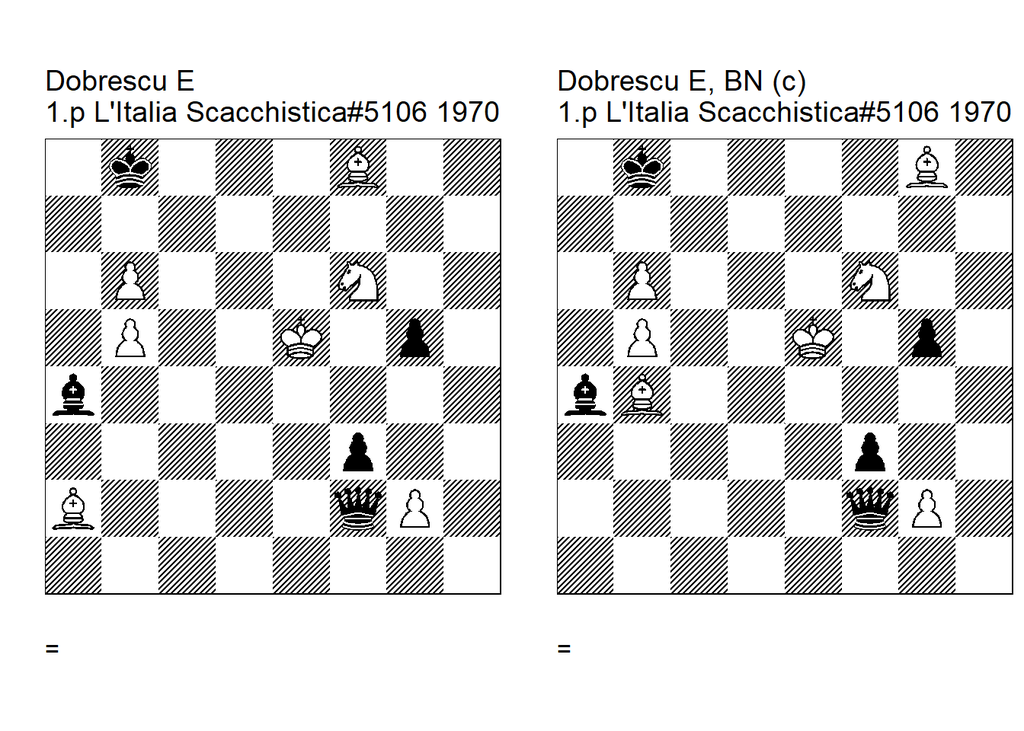

```
Dobrescu E
1.p L'Italia Scacchistica#5106 1970
=3051.32e5b8 cook U1
1k3B2/8/1P3N2/1P2K1p1/b7/5p2/B4qP1/8 w - - 0 1
L'Italia Scacchistica=782 L'Italia Scacchistica/12 (EG#01821). U1: Garcia=M EG=175
1/2009. 1. Bd6+ (1. Bd5! <cook MG> 1... Qe3+ 2. Be4 Qc3+ 3. Kf5 Qd4 4. gxf3 Bxb5 5. Kxg5
Qg1+ 6. Ng4) 1... Kc8 (1... Kb7 2. Bd5+) 2. Be6+ Kb7 (2... Kd8 3. Bc7+ Ke7 4. Bd6+) 3.
Bd5+ Kxb6 4. Bc5+! Qxc5 (4... Kxc5 5. Ne4+ Kxb5 6. Nxf2 fxg2 7. Bxg2) 5. Nd7+ Kxb5 6.
Nxc5 f2! (6... Kxc5 7. Bxf3)  (6... fxg2 7. Bxg2) 7. Ne4! f1=Q 8. Bc4+ Qxc4 9. Nd6+ Kb4
(9... Kc5 10. Nxc4) 10. Nxc4 Kxc4 11. Kf5 1/2-1/2.


Dobrescu E, BN (c)
1.p L'Italia Scacchistica#5106 1970
=3051.32e5b8 (c)
1k4B1/8/1P3N2/1P2K1p1/bB6/5p2/5qP1/8 w - - 0 1
correction: Neuenschwander=B beatochess 29/05/2024. 1. Bd6+ (1. Bd5? Qe2+ 2. Be4 (2. Ne4
Qb2+) 2... Qxb5+) 1... Kc8 (1... Kb7 2. Bd5+) 2. Be6+ Kb7 (2... Kd8 3. Bc7+ Ke7 4. Bd6+)
3. Bd5+ Kxb6 4. Bc5+! Qxc5 (4... Kxc5 5. Ne4+ Kxb5 6. Nxf2 fxg2 7. Bxg2) 5. Nd7+ Kxb5 6.
Nxc5 f2! (6... Kxc5 7. Bxf3)  (6... fxg2 7. Bxg2) 7. Ne4! f1=Q 8. Bc4+ Qxc4 9. Nd6+ Kb4
(9... Kc5 10. Nxc4) 10. Nxc4 Kxc4 11. Kf5 1/2-1/2.
```

### Badai +0031.21h52 (1964). Correction

Date: 2024, May 29

File: Badai1964.pgn

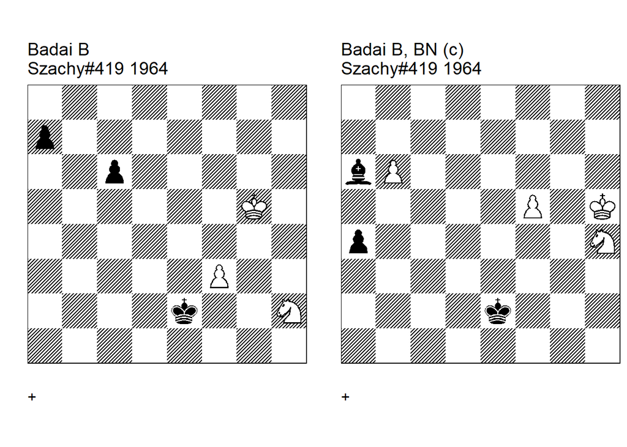

```
Badai B
Szachy#419 1964
+0001.12g5e2 cook U2
8/p7/2p5/6K1/8/5P2/4k2N/8 w - - 0 1
U2: Afek=Y HHdbVI 6-8-2020. 1. f4 a5 2. Nf3! a4 3. Nd4+ Kd3 4. f5 (4. Nxc6? Kc3 5. f5 a3)
4... Kc3 5. f6 (5. Ne2+! <cook YA> 5... Kb2 6. f6 a3 7. Nc3 Kxc3 8. f7 a2 9. f8=Q a1=Q
10. Qg7+ Kb3 11. Qxa1) 5... a3 6. Nb5+ (6. Ne2+!   <cook YA> ) 6... cxb5 7. f7 a2 8. f8=Q
a1=Q (8... Kb2 9. Qb4+ Kc2 10. Qa3 Kb1 11. Qb3+ Ka1 12. Qc2 b4 13. Qc1#) 9. Qf6+ 1-0.


Badai B, BN (c)
Szachy#419 1964
+0031.21h5e2 (c)
8/8/bP6/5P1K/p6N/8/4k3/8 w - - 0 1
correction: Neuenschwander=B beatochess 29/05/2024. 1. Nf3! (1. f6? a3 2. Nf5 Kd2! 3. Nd4
Bc4 4. b7 a2 5. b8=Q a1=Q) 1... a3 2. Nd4+ (2. f6? Bc4!)  2... Kd3 3. f6 (3. Nb3? Kc4! 4.
Nc1 Kd5 5. f6 Kd6! 6. Kg6 Bc4) 3... Kc3 ( 3... a2 4. Nb3 Kc3 5. Na1 Kb2 6. f7 Kxa1 7.
f8=Q) 4. Nb5+! 1-0.
```

# beatochess original studies

Date: 2024, April 1

Files: BN-beatochess2024-1.pgn BN-beatochess2024-2.pgn

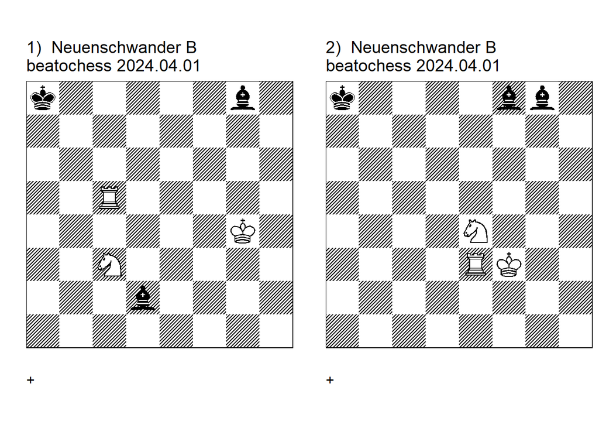

```
1) Neuenschwander B
beatochess 2024.04.01
+0161.00g4a8
k5b1/8/8/2R5/6K1/2N5/3b4/8 w - - 0 1
1. Ne4 Be6+ 2. Kf3 Bb4 (2... Be1 3. Rc1 Bh4 (3... Ba5 4. Ra1) 4. Rh1 Be7 5. Rh8+) 3. Rb5
Bf8 4. Re5 Bd7 (4... Bf7 5. Rf5) 5. Rd5 1-0.


2) Neuenschwander B
beatochess 2024.04.01
+0161.00f3a8
k4bb1/8/8/8/4N3/4RK2/8/8 w - - 0 1
1. Rd3 Be7 2. Rd7 Bh4 3. Kf4 Kb8 (3... Bb3 4. Rh7 Be1 5. Rh1) 4. Ke5 Bc4 5. Kd6 Bf1 6.
Rg7 1-0.
```

Date: 2024, April 2

File: BN-beatochess2024-3.pgn

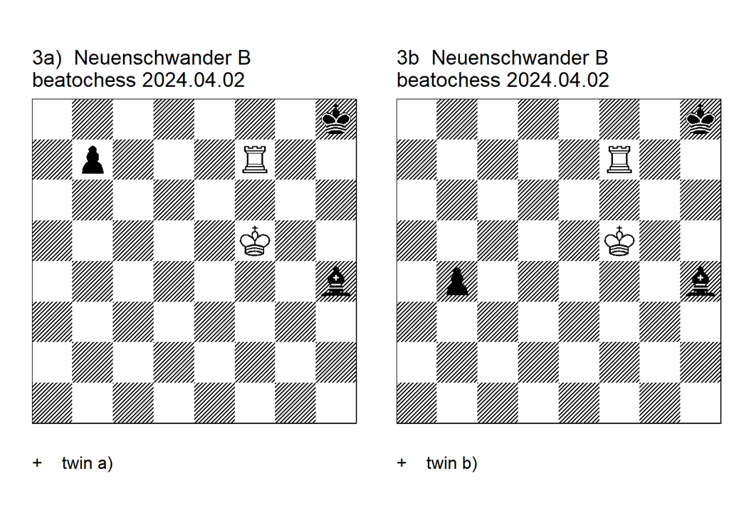

```
3a) Neuenschwander B
beatochess 2024.04.02
+0130.01f5h8 TW
7k/1p3R2/8/5K2/7b/8/8/8 w - - 0 1
1. Rc7! ( Try:  1. Kg6? Kg8 2. Rf4 Bd8 3. Rd4 Bb6 4. Rd6 Ba5) 1... Kg8 2. Rc4! (2. Kg6?
Kf8 3. Rc4 Bd8) 2... Be1 (2... Be7 3. Kg6 b5 (3... Kf8 4. Rc8+) 4. Rc8+ Bf8 5. Rb8)
(2... Bf2 3. Kg6 Kf8 4. Rf4+) 3. Kg6 Kf8 4. Rf4+ Kg8 5. Re4 1-0.


3b Neuenschwander B
beatochess 2024.04.02
+0130.01f5h8 TW
7k/5R2/8/5K2/1p5b/8/8/8 w - - 0 1
1. Kg6! ( Try: 1. Rc7? Kg8 2. Rc4 Be1! 3. Kg6 Kf8 4. Rf4+ Ke7! 5. Re4+ Kd6 6. Rxe1) 1...
Kg8 2. Rf4! Bg3 3. Rg4 Be5 (3... Bd6 4. Rd4)  (3... Bc7 4. Rc4)  (3... Bh2 4. Kf6+ Kf8 5.
Rh4)  (3... Be1 4. Re4)  (3... Bf2 4. Rxb4 Bg3 5. Rg4 Bf2 6. Ra4 Kf8 7. Rf4+) 4. Re4 1-0.
```

Date: 2024, April 26

File: BN-beatochess2024-4.pgn

Date: 2024, May 6

File: BN-beatochess2024-5.pgn

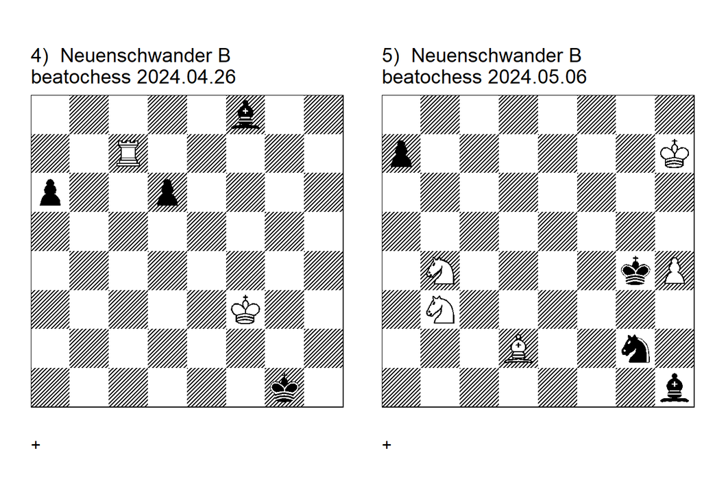

```
4) Neuenschwander B
beatochess 2024.04.26
+0130.02f3g1
5b2/2R5/p2p4/8/8/5K2/8/6k1 w - - 0 1
1. Rf7! (1. Kg3? Bh6! =)  (1. Rb7? d5! =)  (1. Rd7? d5! =)  1... Bh6 2. Rb7! (2. Rh7?
Bc1! =) 2... d5 (2... a5 3. Rb8! a4 (3... Bd2 4. Rb1+ Kh2 5. Rb2) 4. Rg8+ Kf1 5. Rh8)
(2... Bf8 3. Kg3 Kf1 4. Rf7+) 3. Rb6! (3. Rb8? d4! 4. Rg8+ Kf1 5. Rh8 Be3 =) 3... Bf8 4.
Kg3 Kf1 5. Rf6+ 1-0.


5) Neuenschwander B
beatochess 2024.05.06
+0045.11h7g4
8/p6K/8/8/1N4kP/1N6/3B2n1/7b w - - 0 1
1. Nd3 Nxh4 (1... Kxh4 2. Nf2) 2. Nf2+ Kf3 3. Nxh1 Kg2 4. Nd4 (4. Be1? Nf3)  4... Kxh1
(4... Nf3 5. Nxf3 Kxf3 6. Be1 a5 7. Ng3) 5. Bg5! Ng2 6. Nf3 a5 7. Kg6 a4 8. Kf5 a3 9. Ke4
a2 10. Bf6 1-0.
```

# My studies

(currently in the making…)